# Paso 2. Selección de observaciones

Autor/a

Andrés González Santa Cruz

Fecha de publicación

18 de mar, 2025

**Código**

```r
# remover objetos y memoria utilizada
rm(list=ls());gc()
```

```
          used (Mb) gc trigger (Mb) max used (Mb)
Ncells  601357 32.2    1294802 69.2   690688 36.9
Vcells 1152167  8.8    8388608 64.0  1879001 14.4
```

**Código**

```r
#remover imágenes
while(!dev.cur())dev.off()
cat("\014")
```

# Instalar paquetes, etc.

**Código**

```r
#elegir repositorio
if(Sys.info()["sysname"]=="Windows"){
  options(repos = c(CRAN = "https://cran.dcc.uchile.cl/"))
}
options(install.packages.check.source = "yes") # Chequea la fuente de los paquetes

#borrar caché
#system("fc-cache -f -v")

if(Sys.info()["sysname"]=="Windows"){
if (getRversion() != "4.4.1") { stop("Requiere versión de R 4.4.1. Actual: ", getRversion()) }
}
if(Sys.info()["sysname"]=="Linux"){
if (getRversion() != "4.4.1") { stop("Requiere versión de R 4.4.1. Actual: ", getRversion()) }
}

# 0.Fechas y paquetes --------------------------------------------------

# remover objetos y memoria utilizada
rm(list=ls());gc()
```

```
          used (Mb) gc trigger (Mb) max used (Mb)
Ncells  606852 32.5    1294802 69.2  1294802 69.2
Vcells 1165670  8.9    8388608 64.0  1879001 14.4
```

**Código**

```r
# paquetes en R

if (Sys.info()["sysname"] == "Linux") {
  # Verificar si librsvg-2.so.2 ya está instalado
  librsvg_exists <- system("ldconfig -p | grep librsvg-2.so.2", ignore.stdout = TRUE, ignore.stderr = TRUE)

  if (librsvg_exists != 0) {
    message("librsvg no se encontró. Instalando librsvg2-dev...")
    # Actualiza la lista de paquetes e instala librsvg2-dev
    system("sudo apt-get update && sudo apt-get install -y librsvg2-dev")
  } else {
    message("librsvg ya está instalado.")
  }
}

packages <- list(
  # Manipulación de datos y vaisualización
  data = c("dplyr", "lubridate", "ggplot2", "janitor", "ggalluvial", "tidytable", "purrr", "magrittr"),

  # Improtar datos
  rio = c("arrow", "rio", "nanoparquet", "haven"),

  #Analisis_Secuencias_Clustering
  clustering = c("TraMineR", "TraMineRextras", "ggseqplot",  "factoextra",
                                     "cluster", "WeightedCluster", "NbClust"),

  # Diagramar
  diagram = c("DiagrammeR", "rsvg", "DiagrammeRsvg", "webshot", "gtsummary", "cowplot",
                          "grid", "gridExtra", "kableExtra"),

  # Analizar
  analysis = c("epiR", "naniar", "psych", "pROC", "caret", "boot",
               "parallel", "tableone", "sqldf"),

  #optimización y desarrollo
  pacakge_develop = c("devtools", "job", "foreach", "doParallel", "progressr"),

  # Modelamiento y ML
  ml = c("SuperLearner", "glmnet", "randomForest", "missRanger",
         "ranger", "dbarts", "lmtest", "emmeans", "effsize", "rstatix", "stargazer"),

  otros = c("chisq.posthoc.test", "Tmisc", "quarto")
)

# Sys.setenv(CC = "/usr/bin/gcc-12", CXX = "/usr/bin/g++-12") #bajar de gcc 13 a 12
# Sys.setenv(CXXFLAGS = "-O0") # ignorar error
# Sys.setenv(CC = "clang", CXX = "clang++") # si no funciona lo otro, ambiar compilador
#pak::pak("duckdb/duckdb-r")
#install.packages("duckdb", repos = "https://duckdb.r-universe.dev")
if(!require(duckdb)){pak::pkg_install("duckdb/duckdb-r@main?source=false")}
```

**Código**

```r
pak::pak_sitrep()
```

```
* pak version:
- 0.8.0
* Version information:
- pak platform: x86_64-w64-mingw32 (current: x86_64-w64-mingw32, compatible)
- pak sha: 83c979220d4a81011252cee000906a8df833b17c
* Optional packages installed:
- pillar
* Library path:
- C:/Users/andre/AppData/Local/R/win-library/4.4
- C:/Program Files/R/R-4.4.1/library
* pak is installed at C:/Users/andre/AppData/Local/R/win-library/4.4/pak.
* Dependency versions:
- callr      3.7.6
- cli        3.6.2
- curl       5.2.1
- desc       1.4.3
- filelock   1.0.3
- jsonlite   1.8.8
- lpSolve    5.6.20
- pkgbuild   1.4.4
- pkgcache   2.2.2.9000
- pkgdepends 0.7.2.9000
- pkgsearch  3.1.3
- processx   3.8.4
- ps         1.7.6
- R6         2.5.1
- zip        2.3.1
* Dependencies can be loaded
```

**Código**

```r
#pak::sysreqs_check_installed(unique(unlist(packages)))
#pak::lockfile_create(unique(unlist(packages)),  "dependencies_ubuntu.lock", dependencies=T)
#pak::lockfile_install("dependencies_ubuntu2.lock")
#pak::lockfile_install("dependencies_windows2.lock") #saqué doMC
#pak::pak("duckdb/duckdb-r") #si hay error, github version
#https://rdrr.io/cran/pak/man/faq.html
#pak::cache_delete()

#_#_#_#_#_#_#_#_#_#_#_#_#_#_#_#_#_#_#_#_#_#_#_#_#_
#_#_#_#_#_#_#_#_#_#_#_#_#_#_#_#_#_#_#_#_#_#_#_#_#_

library(tidytable)
```

**Código**

```r
if(!require(bpmn)){pak::pak("bergant/bpmn")}
```

**Código**

```r
#_#_#_#_#_#_#_#_#_#_#_#_#_#_#_#_#_#_#_#_#_#_#_#_#_
sum_dates <- function(x){

  cbind.data.frame(
    min= as.Date(min(unclass(as.Date(x)), na.rm=T), origin = "1970-01-01"),
    p001= as.Date(quantile(unclass(as.Date(x)), .001, na.rm=T), origin = "1970-01-01"),
    p005= as.Date(quantile(unclass(as.Date(x)), .005, na.rm=T), origin = "1970-01-01"),
    p025= as.Date(quantile(unclass(as.Date(x)), .025, na.rm=T), origin = "1970-01-01"),
    p25= as.Date(quantile(unclass(as.Date(x)), .25, na.rm=T), origin = "1970-01-01"),
    p50= as.Date(quantile(unclass(as.Date(x)), .5, na.rm=T), origin = "1970-01-01"),
    p75= as.Date(quantile(unclass(as.Date(x)), .75, na.rm=T), origin = "1970-01-01"),
    p975= as.Date(quantile(unclass(as.Date(x)), .975, na.rm=T), origin = "1970-01-01"),
    p995= as.Date(quantile(unclass(as.Date(x)), .995, na.rm=T), origin = "1970-01-01"),
    p999= as.Date(quantile(unclass(as.Date(x)), .999, na.rm=T), origin = "1970-01-01"),
    max= as.Date(max(unclass(as.Date(x)), na.rm=T), origin = "1970-01-01")
  )
}
smd_bin <- function(x,y){
  z <- x*(1-x)
  t <- y*(1-y)
  k <- sum(z,t)
  l <- k/2

  return((x-y)/sqrt(l))

}

theme_custom_sjplot2 <- function(base_size = 12, base_family = "") {
  theme_minimal(base_size = base_size, base_family = base_family) +
    theme(
      # Text elements
      text = element_text(size = base_size, family = base_family),
      plot.title = element_text(face = "bold", hjust = 0.5, size = base_size * 1.2),
      plot.subtitle = element_text(hjust = 0.5, margin = margin(b = 10)),
      axis.title = element_text(size = base_size, face = "bold"),
      axis.text = element_text(size = base_size * 0.8),
      axis.text.x = element_text(angle = 0, hjust = 0.5, vjust = 0.5),
      axis.text.y = element_text(angle = 0, hjust = 1, vjust = 0.5),
      axis.title.x = element_text(margin = margin(t = 10)),
      axis.title.y = element_text(margin = margin(r = 10)),

      # Plot layout
      plot.margin = margin(t = 20, r = 20, b = 20, l = 20),
      panel.grid.major = element_line(color = "grey80"),
      panel.grid.minor = element_blank(),
      legend.position = "right",
      legend.text = element_text(size = base_size * 0.8),
      legend.title = element_text(size = base_size, face = "bold"),
      legend.background = element_rect(fill = "white", colour = NA),
      legend.box.background = element_rect(colour = "grey80", linetype = "solid"),
      legend.key = element_rect(fill = "white", colour = "white")
    )
}

#_#_#_#_#_#_#_#_#_#_#_#_#_#_#_#_#_#_#_#_#_#_#_#_#_#_#_#_#_#_#_#_#_#_#_#_#_#_#_#_
#_#_#_#_#_#_#_#_#_#_#_#_#_#_#_#_#_#_#_#_#_#_#_#_#_#_#_#_#_#_#_#_#_#_#_#_#_#_#_#_
num_cores <- parallel::detectCores() -1
data.table::setDTthreads(threads = num_cores)#restore_after_fork = NULL, throttle = NULL)

#_#_#_#_#_#_#_#_#_#_#_#_#_#_#_#_#_#_#_#_#_#_#_#_#_#_#_#_#_#_#_#_#_#_#_#_#_#_#_#_
#CONFIG #######################################################################
#_#_#_#_#_#_#_#_#_#_#_#_#_#_#_#_#_#_#_#_#_#_#_#_#_#_#_#_#_#_#_#_#_#_#_#_#_#_#_#_

options(scipen=2) #display numbers rather scientific number
```

# Estructurar base datos

- Eliminar registros de menores de 15 años, de las personas que al 2018 tuvieron un registro entre 15-29 años.
- Eliminar duplicados en muchos campos [combinación de: RUN, Establecimiento, Área de atención al egreso, Fecha de ingreso, Fecha d egreso, Glosa previsión, Tramo, Sexo, Edad (en años), Diagnóstico (1 a 5)].
- Añadimos una fecha mínima de egreso por RUN (`min_fecha_egreso_rec24_num`)

**Código**

```r
# Create a new environment to load the data into
env <- new.env()

invisible("Traemos la base de datos")
if (Sys.info()["sysname"] == "Linux") {
  # Load all data into the environment
  #load("H:/Mi unidad/PERSONAL ANDRES/UCH_salud_publica/asignaturas/un_inv_II/20240320.RData", envir = env)
  load("20240405_25.RData", envir = env, verbose = T)

} else {
  # Load all data into the environment
  #load("H:/Mi unidad/PERSONAL ANDRES/UCH_salud_publica/asignaturas/un_inv_II/20240320.RData", envir = env)
  load("20240405_25.RData", envir = env, verbose = T)
}
```

```
Loading objects:
  tt_dtX2023_12_05_DatosEgresosHosp_encrip_s5
  usuarios_ppoo_conadi
  i
  hash_no_ppoo
  cnt_runs_mort
  tt_dtX2023_12_05_DatosEgresosHosp_encrip_s5_adult
  labs_date
  usuarios_no_ppo_flex
  result
  episodios_ppoo_conadi
  def_enc17_21
  .Random.seed
  cnt_runs_s1
  cnt_runs_s2
  result2
  cnt_runs_s3
  cnt_runs_s5
  tt_dtX2023_12_05_DatosEgresosHosp_encrip_s5_prev_adult
  hash_ppoo_conadi
  usuarios_no_ppoo
  disc_negative_tr_days
  hash_no_ppo_flex
  cnt_runs_original_bd
  runs_no_100_chile
  disc_dates_2017_22
  tt_dtX2023_12_05_DatosEgresosHosp_encrip_s5a2
  homolog_estab_misal
  episodios_no_ppo_flex
  labs2_date
  labs2
  disc_nac_nocl
  psych_comorbidity_pattern
  .QuartoInlineRender
  tt_dtX2023_12_05_DatosEgresosHosp_encrip_s5a_prev
  filtered_df_csv
  tt_dtX2023_12_05_DatosEgresosHosp_encrip
  df_estab_tab
  disc_run_erroneos
  result_total
  episodios_no_ppoo
  cnt_runs_s5_adult
  tt_dtX2023_12_05_DatosEgresosHosp_encrip_s5a
  nac_enc17_22
  disc_dates_2017_22_df2
  .main
  disc_large_tr_days
  labs
```

**Código**

```r
# Update 2024-05-10: eliminated people that experienced no SM or SUD related hosp before 2017, but in 2018 still had SM or SUD issues before the first at 15-29
tt_dtX2023_12_05_DatosEgresosHosp_encrip_s5_adult_2 <- filter(env$tt_dtX2023_12_05_DatosEgresosHosp_encrip_s5_adult, !run %in% (env$tt_dtX2023_12_05_DatosEgresosHosp_encrip_s5_adult|> filter(edad_anos<15)|> pull(run)))

paste0('Filtrando <15 \n(n= ',
                    formatC(nrow(tt_dtX2023_12_05_DatosEgresosHosp_encrip_s5_adult_2),
                            format='f', big.mark='.', digits=0),
                    ';\np= ',
                    formatC(length(unique(tt_dtX2023_12_05_DatosEgresosHosp_encrip_s5_adult_2$run)),
                            format='f', big.mark='.', digits=0),')')
```

```
[1] "Filtrando <15 \n(n= 14.038;\np= 6.629)"
```

**Código**

```r
#Update 2024-05-11: Eliminate events of people with duplicated rows in run, area of admission, date of admission and discharge, and the first ICD-10 codes
vector_duplicates<- c("run", "estab_homo",  "areaf_egr", "fecha_ingreso", "fecha_egreso", "glosa_prevision", "benef", "glosa_sexo", "edad_anos", "diag1", "diag2", "diag3", "diag4", "diag5")

tt_dtX2023_12_05_DatosEgresosHosp_encrip_s5_adult_3 <-
  tt_dtX2023_12_05_DatosEgresosHosp_encrip_s5_adult_2|>
  group_by(!!!syms(vector_duplicates))|>
  mutate(n_duplicated=row_number())|>
  ungroup()|>
  filter(n_duplicated<2)

paste0('Eliminamos filas duplicadas en RUN, establecimiento, previsión, tramo, sexo, edad y los primeros 5 diagnósticos <15 \n(n= ',
                    formatC(nrow(tt_dtX2023_12_05_DatosEgresosHosp_encrip_s5_adult_2),
                            format='f', big.mark='.', digits=0),
                    ';\np= ',
                    formatC(length(unique(tt_dtX2023_12_05_DatosEgresosHosp_encrip_s5_adult_2$run)),
                            format='f', big.mark='.', digits=0),')')
```

```
[1] "Eliminamos filas duplicadas en RUN, establecimiento, previsión, tramo, sexo, edad y los primeros 5 diagnósticos <15 \n(n= 14.038;\np= 6.629)"
```

**Código**

```r
# Extract only the desired object
data_long <- tt_dtX2023_12_05_DatosEgresosHosp_encrip_s5_adult_3

data_long <- group_by(data_long, run)|>
  mutate(min_fecha_egreso_rec24_num= min(fecha_egreso_rec24_num))|>
  ungroup()
```

## Combinar base con código hospitales

Traemos las bases de datos, junto con algunas bases de referencia para contrastar el código de establecimiento. Traemos la base de datos enviada el 2024 con el código de establecimiento, junto con algunos libros de código para referencia. También eliminamos filas duplicadas y todo lo guardamos en `EH_2010_2022_Pasantes_v2_encrip`.

**Código**

```r
invisible("Traemos la base de datos")
if (Sys.info()["sysname"] == "Linux") {
#dtX2023_12_05_DatosEgresosHosp_encrip<-rio::import("~/workspace/extracted/20231205_hosp_mod20240404.parquet.gzip")
EH_2010_2022_Pasantes_v2_encrip <- readr::read_delim("_data/EH_2010_2022_Pasantes_v2_encrip.csv",
                                              delim = ";", escape_double = FALSE, trim_ws = TRUE) |> as_tidytable()

} else {
EH_2010_2022_Pasantes_v2_encrip <- readr::read_delim("_data/EH_2010_2022_Pasantes_v2_encrip.csv",
                                              delim = ";", escape_double = FALSE, trim_ws = TRUE)|> as_tidytable()
}
```

**Código**

```r
vector_duplicates<- c("RUN", "ESTAB_HOMO",  "AREAF_EGR", "FECHA_INGRESO", "FECHA_EGRESO", "GLOSA_PREVISION", "BENEF", "GLOSA_SEXO", "EDAD_ANOS", "DIAG1", "DIAG2", "DIAG3", "DIAG4", "DIAG5")

gc()


invisible("Estamos descartando duplicados")
EH_2010_2022_Pasantes_v2_encrip <-
  EH_2010_2022_Pasantes_v2_encrip|>
  group_by(!!!syms(vector_duplicates))|>
  mutate(n_duplicated=row_number())|>
  ungroup()|>
  filter(n_duplicated<2)

paste0('Eliminamos filas duplicadas en RUN, establecimiento, previsión, tramo, sexo, edad y los primeros 5 diagnósticos <15 \n(n= ',
                    formatC(nrow(EH_2010_2022_Pasantes_v2_encrip),
                            format='f', big.mark='.', digits=0),
                    ';\np= ',
                    formatC(length(unique(EH_2010_2022_Pasantes_v2_encrip$RUN)),
                            format='f', big.mark='.', digits=0),')')
```

**Código**

```r
#[1] "Eliminamos filas duplicadas en RUN, establecimiento, previsión, tramo, sexo, edad y los primeros 5 diagnósticos <15 \n(n= 20.952.449;\np= 9.646.325)"

#_#_#_#_#_#_#_#_#_#_#_#_#_#_#_#_#_#_#_#_#_#_#_#_#_#_#_#_#_#_#_#_#_#_#_#_#_#_#_#_#_#_#_#_#_#_#_#_#_
#_#_#_#_#_#_#_#_#_#_#_#_#_#_#_#_#_#_#_#_#_#_#_#_#_#_#_#_#_#_#_#_#_#_#_#_#_#_#_#_#_#_#_#_#_#_#_#_#_
#_#_#_#_#_#_#_#_#_#_#_#_#_#_#_#_#_#_#_#_#_#_#_#_#_#_#_#_#_#_#_#_#_#_#_#_#_#_#_#_#_#_#_#_#_#_#_#_#_
invisible("Obtener base de datos de Establecimientos")
gc()
X717508813_Establecimientos_ChileDEIS_MINSAL_29_04_2022 <- readxl::read_excel("_antecedentes/717508813-Establecimientos-ChileDEIS-MINSAL-29-04-2022.xlsx", sheet = "Establecimientos Vig", skip = 1)|>janitor::clean_names()
```

**Código**

```r
X717508813_Establecimientos_ChileDEIS_MINSAL_cerrado_29_04_2022 <- readxl::read_excel("_antecedentes/717508813-Establecimientos-ChileDEIS-MINSAL-29-04-2022.xlsx", sheet = "Establecimientos Cerrados", skip = 1)|>janitor::clean_names()|>
  mutate(codigo_vigente=as.numeric(codigo_vigente))
```

[output not shown]

Unimos la base de datos más reciente con la base de datos que estoy trabajando. La nueva base se llama `data_long_establecimiento`. Una forma de unirlos fue en base a RUN, fecha de ingreso (formateando la original de DEIS a %YYYY-%mm-%dd), fecha de egreso (formato DEIS) y más importante, con el código de establecimiento proporcionado en 2023 pero en sus primeros 5 dígitos vs. el código actual. Todo lo anterior, con la finalidad de maximizar la posibilidad de encontrar registros pareados únicos (evitar n:n y por tanto tener una unión ambigua de los datos).

**Código**

```r
gc()
```

```
             used    (Mb) gc trigger    (Mb)   max used    (Mb)
Ncells   12474723   666.3   19114322  1020.9   19114322  1020.9
Vcells 3278082967 25009.8 5468153679 41718.8 4171205205 31823.8
```

**Código**

```r
invisible("Unión con la base de datos corregida")
data_long_establecimiento<-
  data_long|>
  mutate(fecha_ingreso_rec_fmt= as.Date(fecha_ingreso_rec), fecha_egreso_rec_fmt= as.Date(fecha_egreso_rec))|>
  #select(run, estab, fecha_ingreso_rec, fecha_egreso_rec, estab, estab_homo)|>
  left_join(mutate(EH_2010_2022_Pasantes_v2_encrip[,c("RUN", "FECHA_INGRESO_FMT_DEIS", "FECHA_EGRESO_FMT_DEIS", "ESTAB", "ESTAB_HOMO", "TIPO_EDAD","DIAG1", "DIAG2", "DIAG3")], estab_homo_five=as.numeric(stringr::str_sub(ESTAB_HOMO, 1, 5))),
                     by=c("run"="RUN", "fecha_ingreso_rec_fmt"="FECHA_INGRESO_FMT_DEIS", "fecha_egreso_rec_fmt"="FECHA_EGRESO_FMT_DEIS", "tipo_edad"="TIPO_EDAD", "diag1"="DIAG1", "diag2"="DIAG2", "diag3"="DIAG3", "estab_homo"="estab_homo_five")) |>
    (\(df) {
    print(cat(paste0("Obs: ", formatC(nrow(df), big.mark="."), "\n")))
    print(cat(paste0("RUNs: ", formatC(distinct(df, run)|> nrow(), big.mark="."), "\n")))
    df
  })()
```

```
Obs: 14.037
NULL
```

```
RUNs: 6.629
NULL
```

**Código**

```r
# Total: 14037 #perdemos una observación
# NULL
# Total: 6629
# NULL

#:#:#:#:#:#:#:#:#:#:#:#:#:#:#:#:#:#:#:#:#:#:#:#:#:#:#:#:#:#:#:#:#:#:#:#:#:#:#:#:
#:#:#:#:#:#:#:#:#:#:#:#:#:#:#:#:#:#:#:#:#:#:#:#:#:#:#:#:#:#:#:#:#:#:#:#:#:#:#:#:
if(
  nrow(data_long_establecimiento) >nrow(data_long)){warning("Producto de la unión se añaden filas (hay un pareamiento 1 a >1)")}
```

**Código**

```r
paste0("Pacientes duplicados (aunque sólo vemos duplicados en términos de RUN, fecha de ingreso y fecha de egreso aquí): ",
data_long_establecimiento|>
  janitor::get_dupes(run, fecha_ingreso_rec_fmt, fecha_egreso_rec_fmt)|>
    distinct(run)|>nrow(),
"; eventos: ",
data_long_establecimiento|>
  janitor::get_dupes(run, fecha_ingreso_rec_fmt, fecha_egreso_rec_fmt)|>
  nrow()
)
```

```
[1] "Pacientes duplicados (aunque sólo vemos duplicados en términos de RUN, fecha de ingreso y fecha de egreso aquí): 6; eventos: 16"
```

**Código**

```r
#[1] "Pacientes duplicados: 6; eventos: 16" # se mantiene del 2024


#:#:#:#:#:#:#:#:#:#:#:#:#:#:#:#:#:#:#:#:#:#:#:#:#:#:#:#:#:#:#:#:#:#:#:#:#:#:#:#:
#:#:#:#:#:#:#:#:#:#:#:#:#:#:#:#:#:#:#:#:#:#:#:#:#:#:#:#:#:#:#:#:#:#:#:#:#:#:#:#:

cat("Dado que había duplicados, seleccionamos el primer elemento que coincida. Aunque llama la atención que no agrega observaciones a pesar de eso (si hay 1:n, debiese aniadir a x obs)")
```

```
Dado que había duplicados, seleccionamos el primer elemento que coincida. Aunque llama la atención que no agrega observaciones a pesar de eso (si hay 1:n, debiese aniadir a x obs)
```

**Código**

```r
data_long_establecimiento<-
  data_long|>
  mutate(fecha_ingreso_rec_fmt= as.Date(fecha_ingreso_rec), fecha_egreso_rec_fmt= as.Date(fecha_egreso_rec))|>
  #select(run, estab, fecha_ingreso_rec, fecha_egreso_rec, estab, estab_homo)|>
  left_join(mutate(EH_2010_2022_Pasantes_v2_encrip[,c("RUN", "FECHA_INGRESO_FMT_DEIS", "FECHA_EGRESO_FMT_DEIS", "ESTAB", "ESTAB_HOMO", "TIPO_EDAD", "DIAG1", "DIAG2", "DIAG3")], estab_homo_five=as.numeric(stringr::str_sub(ESTAB_HOMO, 1, 5))),
                     by=c("run"="RUN", "fecha_ingreso_rec_fmt"="FECHA_INGRESO_FMT_DEIS", "fecha_egreso_rec_fmt"="FECHA_EGRESO_FMT_DEIS", "tipo_edad"="TIPO_EDAD", "diag1"="DIAG1", "diag2"="DIAG2", "diag3"="DIAG3", "estab_homo"="estab_homo_five"), multiple="first") |>
    (\(df) {
    print(cat(paste0("Obs: ", formatC(nrow(df), big.mark="."), "\n")))
    print(cat(paste0("RUNs: ", formatC(distinct(df, run)|> nrow(), big.mark="."), "\n")))
    df
  })()
```

```
Obs: 14.037
NULL
```

```
RUNs: 6.629
NULL
```

Ahora que tenemos el código de establecimiento, unimos con los libros de códigos y directorios de establecimientos. Particularmente, traemos nombres, nivel de complejidad, modalidad de atención, ubicación, tipo de establecimiento, código de comuna y región. En caso que algún campo no se encuentre en la base `X717508813_Establecimientos_ChileDEIS_MINSAL_29_04_2022`, se toma de `X717508813_Establecimientos_ChileDEIS_MINSAL_cerrado_29_04_2022`.

**Código**

```r
gc()
```

```
             used    (Mb) gc trigger    (Mb)   max used    (Mb)
Ncells   12530116   669.2   19114322  1020.9   19114322  1020.9
Vcells 3279909380 25023.8 5468153679 41718.8 4171205205 31823.8
```

**Código**

```r
data_long_establecimiento_2024_std<-
  data_long_establecimiento |>
  left_join(janitor::clean_names(X717508813_Establecimientos_ChileDEIS_MINSAL_29_04_2022)[,c("codigo_antiguo", "codigo_vigente", "codigo_comuna", "codigo_region", "tiene_servicio_de_urgencia", "nombre_oficial", "tipo_establecimiento", "nivel_de_atencion", "tipo_de_prestador_sistema_de_salud", "longitud_grados_decimales", "latitud_grados_decimales", "nivel_de_complejidad", "modalidad_de_atencion")], by= c("ESTAB_HOMO"="codigo_vigente"), suffix = c("", "_est"))|>
  left_join(janitor::clean_names(X717508813_Establecimientos_ChileDEIS_MINSAL_cerrado_29_04_2022)[,c("codigo_antiguo", "codigo_vigente", "codigo_comuna", "codigo_region", "tiene_servicio_de_urgencia", "nombre_oficial", "tipo_establecimiento", "nivel_de_atencion", "tipo_de_prestador_sistema_de_salud", "longitud_grados_decimales", "latitud_grados_decimales", "nivel_de_complejidad", "modalidad_de_atencion")], by= c("ESTAB_HOMO"="codigo_vigente"), suffix = c("", "_cerrado"))|>
  mutate(longitud_grados_decimales_cerrado= as.numeric(longitud_grados_decimales_cerrado), latitud_grados_decimales_cerrado= as.numeric(latitud_grados_decimales_cerrado)) |>
  # Para generar las variables, vemos si está en una de las bases, si no, ponemos el valor de la otra
  mutate(
    codigo_antiguo= ifelse(is.na(codigo_antiguo),codigo_antiguo_cerrado, codigo_antiguo),
    codigo_comuna= ifelse(is.na(codigo_comuna),codigo_comuna_cerrado, codigo_comuna),
    codigo_region= ifelse(is.na(codigo_region),codigo_region_cerrado, codigo_region),
    tiene_servicio_de_urgencia= ifelse(is.na(tiene_servicio_de_urgencia),tiene_servicio_de_urgencia_cerrado, tiene_servicio_de_urgencia),
    nombre_oficial= ifelse(is.na(nombre_oficial),nombre_oficial_cerrado, nombre_oficial),
    tipo_establecimiento= ifelse(is.na(tipo_establecimiento),tipo_establecimiento_cerrado, tipo_establecimiento),
    nivel_de_atencion= ifelse(is.na(nivel_de_atencion),nivel_de_atencion_cerrado, nivel_de_atencion),
    tipo_de_prestador_sistema_de_salud= ifelse(is.na(tipo_de_prestador_sistema_de_salud),tipo_de_prestador_sistema_de_salud_cerrado, tipo_de_prestador_sistema_de_salud),
    longitud_grados_decimales= ifelse(is.na(longitud_grados_decimales),longitud_grados_decimales_cerrado, longitud_grados_decimales),
    latitud_grados_decimales= ifelse(is.na(latitud_grados_decimales),latitud_grados_decimales_cerrado, latitud_grados_decimales),
    nivel_de_complejidad= ifelse(is.na(nivel_de_complejidad),nivel_de_complejidad_cerrado, nivel_de_complejidad),
    modalidad_de_atencion= ifelse(is.na(modalidad_de_atencion),modalidad_de_atencion_cerrado, modalidad_de_atencion))|>
  select(-matches("\\$|\\_cerrado$"))|>
    (\(df) {
    print(cat(paste0("Obs: ", formatC(nrow(df), big.mark="."), "\n")))
    print(cat(paste0("RUNs: ", formatC(distinct(df, run)|> nrow(), big.mark="."), "\n")))
    df
  })()
```

```
Obs: 14.037
NULL
```

```
RUNs: 6.629
NULL
```

**Código**

```r
cat("Perdidos en establecimiento (TRUE= perdidos)\n");as.numeric(table(is.na(data_long_establecimiento_2024_std$ESTAB_HOMO)))
```

```
Perdidos en establecimiento (TRUE= perdidos)
```

```
[1] 14037
```

**Código**

```r
table(is.na(data_long_establecimiento_2024_std$ESTAB))
```

```
FALSE
14037
```

**Código**

```r
invisible("Por lo visto no ")

invisible("Ver si se generan más filas producto de la unión")
if(
  data_long_establecimiento_2024_std|>nrow() >data_long_establecimiento|>nrow()){stop("Producto de la unión se añaden filas (hay un pareamiento 1 a >1)")}
```

# Formatear base de datos

Una vez que logramos recuperar la información de interés, estandarizamos datos y normalizamos valores, limpiando valores erróneos, etc.

Primero, eliminamos variables que no existen en caso que las hubiera.

**Código**

```r
data_long_establecimiento_2024_std$nac_chile<-NULL
```

**Código**

```r
data_long_establecimiento_2024_std$nac_chile<-NULL
```

**Código**

```r
data_long_establecimiento_2024_std$perc_nac_cl<-NULL
```

## Imputación Previsión y Tramo

Hubo una columna clave que tenía una categoría de respuesta (“Desconocido”) altamente perjudicial para nuestros análisis. Dado el bajo porcentaje de usuarios en esta categoría (<1%), se decidió imputar, asumiendo que hubo una migración a otro sistema previsional es improbable.

**Código**

```r
data_long_establecimiento_2024_std |>
  janitor::tabyl(glosa_prevision) |>
  mutate(percent= sprintf("%1.1f",percent*100)) |>
  knitr::kable("markdown", caption= "Previsión (total, no anidado por usuario)", col.names=c("Previsión", "n", "porcentaje"))
```

Previsión (total, no anidado por usuario)

| Previsión | n | porcentaje |
| --- | --- | --- |
| CAPREDENA | 169 | 1.2 |
| DESCONOCIDO | 83 | 0.6 |
| DIPRECA | 159 | 1.1 |
| FONASA | 9874 | 70.3 |
| ISAPRE | 3423 | 24.4 |
| NINGUNA | 137 | 1.0 |
| SISA | 192 | 1.4 |

Vemos la anidación de registros por paciente.

**Código**

```r
message(paste0("Número de pacientes con previsión desconocida (al menos un registro): ",
data_long_establecimiento_2024_std|>
   group_by(run)|>
   summarise(sum_total= n(),
             sum_desc= sum(glosa_prevision=="DESCONOCIDO"),
             sum_capr=sum(glosa_prevision=="CAPREDENA"),
             sum_dipr=sum(glosa_prevision=="DIPRECA"),
             sum_fonas=sum(glosa_prevision=="FONASA"),
             sum_isapr=sum(glosa_prevision=="ISAPRE"),
             sum_ning=sum(glosa_prevision=="NINGUNA"),
             sum_sisa=sum(glosa_prevision=="SISA"))|>
  filter(sum_desc>0)|>
  nrow()
))
```

```
Número de pacientes con previsión desconocida (al menos un registro): 73
```

**Código**

```r
#[1] "Número de pacientes con previsión desconocida: 62 a 73"


message(paste0("Número de pacientes con previsión desconocida y sólo ese valor: ",
data_long_establecimiento_2024_std |>
  group_by(run) |>
  summarise(
    sum_total = n(),
    perc_desc = sum(glosa_prevision == "DESCONOCIDO") / n(),
    perc_capr = sum(glosa_prevision == "CAPREDENA") / n(),
    perc_dipr = sum(glosa_prevision == "DIPRECA") / n(),
    perc_fonas = sum(glosa_prevision == "FONASA") / n(),
    perc_isapr = sum(glosa_prevision == "ISAPRE") / n(),
    perc_ning = sum(glosa_prevision == "NINGUNA") / n(),
    perc_sisa = sum(glosa_prevision == "SISA") / n()
  ) |>
  filter(perc_desc==1)|>
  nrow()
))
```

```
Número de pacientes con previsión desconocida y sólo ese valor: 18
```

**Código**

```r
message(paste0("Número de pacientes con previsión desconocida y otros: ",
data_long_establecimiento_2024_std |>
  group_by(run) |>
  summarise(
    sum_total = n(),
    perc_desc = sum(glosa_prevision == "DESCONOCIDO") / n(),
    perc_capr = sum(glosa_prevision == "CAPREDENA") / n(),
    perc_dipr = sum(glosa_prevision == "DIPRECA") / n(),
    perc_fonas = sum(glosa_prevision == "FONASA") / n(),
    perc_isapr = sum(glosa_prevision == "ISAPRE") / n(),
    perc_ning = sum(glosa_prevision == "NINGUNA") / n(),
    perc_sisa = sum(glosa_prevision == "SISA") / n()
  ) |>
  filter(perc_desc<1 & perc_desc>0)|>
  nrow()
))
```

```
Número de pacientes con previsión desconocida y otros: 55
```

**Código**

```r
message(paste0("Número de pacientes con previsión desconocida (más de 1 registro): ",
data_long_establecimiento_2024_std|>
   group_by(run)|>
   summarise(sum_total= n(),
             sum_desc= sum(glosa_prevision=="DESCONOCIDO"),
             sum_capr=sum(glosa_prevision=="CAPREDENA"),
             sum_dipr=sum(glosa_prevision=="DIPRECA"),
             sum_fonas=sum(glosa_prevision=="FONASA"),
             sum_isapr=sum(glosa_prevision=="ISAPRE"),
             sum_ning=sum(glosa_prevision=="NINGUNA"),
             sum_sisa=sum(glosa_prevision=="SISA"))|>
   filter(sum_desc>1)|>
   nrow()
))
```

```
Número de pacientes con previsión desconocida (más de 1 registro): 7
```

**Código**

```r
#Número de pacientes con previsión desconocida: 1 # de 6 a 7 al 2025-03-15
```

**Código**

```r
bpmn_fig<-
bpmn::bpmn("_figs/diagram_imputacion_prev_isapre_25.bpmn")
bpmn_fig
```

[interactive chart not shown]

**Código**

[figure not shown]

```r
htmlwidgets::saveWidget(bpmn_fig,
                  "_figs/_diagram_imputacion_prev_isapre_25.html")
webshot::webshot("_figs/_diagram_imputacion_prev_isapre_25.html",
                 "_figs/_diagram_imputacion_prev_isapre_25.png",
                 vwidth = 300*1.2, vheight = 300,  zoom=10, expand=100)  # Prueba con diferentes coordenadas top, left, width, and height.
```

La lógica es la siguiente:

- Contar registros por previsión para cada paciente
- Enfocarse en quienes tienen previsión “DESCONOCIDO”
- Decidir la previsión más probable según la frecuencia en sus otros registros
- En caso de ambigüedad, etiquetar claramente con “IMPUTAR”
- Corregir nombres finales para ser interpretados en la columna `reemplazo`

**Código**

```r
data_long_est_24_std_imp_prev <-
  data_long_establecimiento_2024_std |>
  group_by(run) |>
  summarise(
    sum_desc = sum(glosa_prevision == "DESCONOCIDO"),
    sum_capr = sum(glosa_prevision == "CAPREDENA"),
    sum_dipr = sum(glosa_prevision == "DIPRECA"),
    sum_fonas = sum(glosa_prevision == "FONASA"),
    sum_isapr = sum(glosa_prevision == "ISAPRE"),
    sum_ning = sum(glosa_prevision == "NINGUNA"),
    sum_sisa = sum(glosa_prevision == "SISA")
  ) |>
  filter(sum_desc>0) |>
  rowwise() |>
  mutate(reemplazo = {
    # Get all sum_ values excluding sum_desc
    sums <- c(sum_capr, sum_dipr, sum_fonas, sum_isapr, sum_ning, sum_sisa)
    names_sums <- c("sum_capr", "sum_dipr", "sum_fonas", "sum_isapr", "sum_ning", "sum_sisa")

    if (sum_desc == 1) {
      max_val <- max(sums)
      indices_max <- which(sums == max_val)
      names_max <- names_sums[indices_max]

      # Exclude sum_isapr if possible
      if ("sum_isapr" %in% names_max && length(names_max) > 1) {
        names_max <- names_max[names_max != "sum_isapr"]
      }
      if (length(names_max) == 1) {
        names_max
      } else {
        "IMPUTAR"
      }
    } else if (sum_desc > 1) {
      # Find columns with values >= sum_desc
      valid_cols <- names_sums[sums >= sum_desc]
      if (length(valid_cols) == 1) {
        valid_cols
      } else if (length(valid_cols) > 1) {
        # More than one valid column, choose the one with max value or any if tied
        max_val_cols <- max(sums[sums >= sum_desc])
        max_cols <- names_sums[which(sums == max_val_cols)]
        max_cols[1]  # Choose the first one if tied
      } else {
        "IMPUTAR"
      }
    } else {
      "IMPUTAR"
    }
  }) |>
  ungroup() |>
  mutate(reemplazo_rec= case_when(reemplazo=="sum_capr"~ "CAPREDENA",
                                  grepl("sum_dipr",reemplazo)~ "DIPRECA",
                                  grepl("sum_fonas",reemplazo)~ "FONASA",
                                  grepl("sum_sisa",reemplazo)~ "SISA",
                                  grepl("sum_isapr",reemplazo)~ "ISAPRE",
                                  grepl("sum_capr",reemplazo)~ "CAPREDENA",
                                  grepl("sum_ning",reemplazo)~ "NINGUNA",
                                  T~reemplazo))

data_long_est_24_std_imp_prev |>
  janitor::tabyl(reemplazo_rec) |>
  mutate(percent= sprintf("%1.1f",percent*100)) |>
  knitr::kable("markdown", caption="Resultado de aplicar el árbol de decisión (candidatos reemplazo)", col.names=c("Previsión", "n", "proporción"))
```

Resultado de aplicar el árbol de decisión (candidatos reemplazo)

| Previsión | n | proporción |
| --- | --- | --- |
| DIPRECA | 3 | 4.1 |
| FONASA | 35 | 47.9 |
| IMPUTAR | 18 | 24.7 |
| ISAPRE | 12 | 16.4 |
| SISA | 5 | 6.8 |

Ahora aplicamos las reglas sobre la base, reemplazando los valores en base RUNs (supuesto de invarianza en el tiempo).

**Código**

```r
data_long_est_24_std_imp_rec_prev <-
  data_long_establecimiento_2024_std |>
  left_join(data_long_est_24_std_imp_prev[, c("run", "reemplazo_rec")], by = "run") |>
  (\(df) {
    if (nrow(df) > nrow(data_long_establecimiento_2024_std)) {
      stop("left join added rows")
    }
    df
  })() |>
  mutate(
    glosa_prevision_rec = ifelse(!is.na(reemplazo_rec), reemplazo_rec, glosa_prevision),
    glosa_prevision_rec = ifelse(glosa_prevision_rec == "IMPUTAR", NA, glosa_prevision_rec)
  )

invisible("eliminamos columnas de no interés")
data_long_est_24_std_imp_rec_prev$reemplazo_rec<-NULL

data_long_est_24_std_imp_rec_prev |>
  filter(is.na(glosa_prevision_rec)) |>
    (\(df) {
    print(cat(paste0("A imputar, Obs: ", formatC(nrow(df), big.mark="."), "\n")))
    print(cat(paste0("A imputar, RUNs: ", formatC(distinct(df, run)|> nrow(), big.mark="."), "\n")))
  })()
```

```
A imputar, Obs: 25
NULL
```

```
A imputar, RUNs: 18
NULL
```

**Código**

```r
invisible("Añadimos más n")
data_long_est_24_std_imp_rec_prev |>
  janitor::tabyl(glosa_prevision_rec)|>
  knitr::kable("markdown", caption="Resultado de aplicar el árbol de decisión en la base de datos general", col.names= c("Previsión", "n", "proporción", "proporción válida"))
```

Resultado de aplicar el árbol de decisión en la base de datos general

| Previsión | n | proporción | proporción válida |
| --- | --- | --- | --- |
| CAPREDENA | 168 | 0.0119684 | 0.0119897 |
| DIPRECA | 166 | 0.0118259 | 0.0118470 |
| FONASA | 9911 | 0.7060625 | 0.7073223 |
| ISAPRE | 3436 | 0.2447816 | 0.2452184 |
| NINGUNA | 134 | 0.0095462 | 0.0095632 |
| SISA | 197 | 0.0140343 | 0.0140594 |
| NA | 25 | 0.0017810 | NA |

Para el resto, hacer imputación probabilística. Se utilizaron las siguientes variables predictoras:

- Fecha de ingreso más antigua (`min_fecha_egreso_rec24_num`)
- Pertenencia o autoidentificación a algún pueblo originario (`inclusivo_real_historico`)
- Edad mínima en años (ingreso más antiguo) (`min_edad_anos`)
- Sexo (`glosa_sexo`)
- Establecimiento (`ESTAB_HOMO`)

**Código**

```r
gc()
```

```
             used    (Mb) gc trigger    (Mb)   max used    (Mb)
Ncells   12658829   676.1   19114322  1020.9   19114322  1020.9
Vcells 3283909839 25054.3 5468153679 41718.8 4171205205 31823.8
```

**Código**

```r
invisible("2025-03-15: Dejo los que corresponden a fechas menores al 2018. Saqué códigos z porque era algo exploratorio. A mi me importaba usar la base de datos y ahora no la necesito")
ttos_filt2<-
  env$tt_dtX2023_12_05_DatosEgresosHosp_encrip |>
  filter(run %in% unique(data_long_est_24_std_imp_rec_prev$run)) |>
  filter(fecha_ingreso_rec24<"2018-01-01") |>
  arrange(run, fecha_ingreso_rec24) |>
  mutate(dias_en_tto=fecha_egreso_rec24-fecha_ingreso_rec24) |>
  mutate(dias_fuera_tto=lead(fecha_ingreso_rec24)-fecha_egreso_rec24) |>
  group_by(run) |>
  summarise(promedio_dias_fuera_tto= mean(dias_fuera_tto, na.rm=T),
                   mediana_dias_fuera_tto= quantile(dias_fuera_tto, .5, na.rm=T),
                   promedio_dias_tto= mean(dias_en_tto),
                   mediana_dias_tto= quantile(dias_en_tto, .5),
                   ttos= n()) |>
  ungroup()

#_#_#_#_#_#_#_#_#_#_#_#_#_#_#_#_#_#_#_#_#_#_#_#_#_#_#_#_#_#_#_#_#_#_#_#_#_#_#_#_#_#_
#_#_#_#_#_#_#_#_#_#_#_#_#_#_#_#_#_#_#_#_#_#_#_#_#_#_#_#_#_#_#_#_#_#_#_

cat("Añadiendo los datos históricos de días de tratamiento previos al 2018 y el promedio de días en tratamiento, genero una base para imputación")
```

```
Añadiendo los datos históricos de días de tratamiento previos al 2018 y el promedio de días en tratamiento, genero una base para imputación
```

**Código**

```r
data_long_est_24_std_imp_rec_prev2 <-
  left_join(data_long_est_24_std_imp_rec_prev, ttos_filt2[,c("run", "promedio_dias_tto", "ttos")], by="run")

invisible("Si producto de la unión se añaden más filas, generar error. De lo contrario, sobreescribo data_long_est_24_std_imp_rec_prev y elimino la base anterior")
if(nrow(data_long_est_24_std_imp_rec_prev2)>
   nrow(data_long_est_24_std_imp_rec_prev)){
     stop("Se generaron filas")
     }else {
       data_long_est_24_std_imp_rec_prev<-data_long_est_24_std_imp_rec_prev2; rm(data_long_est_24_std_imp_rec_prev2)
     }
#_#_#_#_#_#_#_#_#_#_#_#_#_#_#_#_#_#_#_#_#_#_#_#_#_#_#_#_#_#_#_#_#_#_#_#_#_#_#_#_#_#_
#_#_#_#_#_#_#_#_#_#_#_#_#_#_#_#_#_#_#_#_#_#_#_#_#_#_#_#_#_#_#_#_#_#_#_
set.seed(2125)
data_long_est_24_std_imp_rec_imp<-
  missRanger::missRanger(
    formula =  glosa_prevision_rec ~ min_fecha_egreso_rec24_num+ inclusivo_real_historico+ min_edad_anos+ glosa_sexo+ ESTAB_HOMO,#+ ttos+ promedio_dias_tto+ diag1,#+ ttos+ promedio_dias_tto,
    data= data_long_est_24_std_imp_rec_prev|>
      dplyr::group_by(run)|>
      dplyr::mutate( min_edad_anos=min(edad_anos, na.rm=T))|>
      dplyr::ungroup()|>
      dplyr::mutate(ttos=ifelse(!is.na(ttos),ttos, 0),  promedio_dias_tto= ifelse(!is.na( promedio_dias_tto),as.numeric( promedio_dias_tto),0)),
    num.trees = 1800,
    pmm.k = 5,
    returnOOB=T,
    maxiter= 500,
    verbose = 2,
    seed = 2125)
```

```
Missing value imputation by random forests
```

```
Variables to impute:        glosa_prevision_rec
Variables used to impute:   min_fecha_egreso_rec24_num, inclusivo_real_historico, min_edad_anos, glosa_sexo, ESTAB_HOMO

    gls_p_
iter 1: 0.0964
iter 2: 0.0970
```

**Código**

```r
invisible("Se generó un oob mayor, y hubo más error de clasificación si controlaba por numero de ttos. previos y días en tto.")
```

El rendimiento predictivo se evaluó mediante la tasa de error fuera de bolsa (OOB), obteniendo una tasa de clasificación OOB de 9.6%, que indica la capacidad predictiva del modelo para estimar correctamente los valores faltantes.

Posteriormente unimos previsión y tramo en `prev_benef` y generamos la categoría recodificada de acuerdo a nuestros intereses (agrupando tramos de FONASA en AB y CD y agrupamos FFAA e ISAPRE. Finalmente, luego de retroalimentación con los profesores, dejamos FFAA e ISAPRE diferenciados, y agrupamos los tramos de FONASA en A, BC y D.

**Código**

```r
gc()
```

```
             used    (Mb) gc trigger    (Mb)   max used    (Mb)
Ncells   13789469   736.5   26401490  1410.0   19114322  1020.9
Vcells 3285790161 25068.6 5468153679 41718.8 4171205205 31823.8
```

**Código**

```r
data_long_est_24_std_imp_rec_imp$prev_benef<-
  glue::glue("{factor(data_long_est_24_std_imp_rec_imp$glosa_prevision_rec)} {factor(data_long_est_24_std_imp_rec_imp$benef)}")
data_long_est_24_std_imp_rec_imp$prev_benef_rec <-
  car::recode(data_long_est_24_std_imp_rec_imp$prev_benef,
              "'CAPREDENA NA'='ISAPRE/FFAA';'DIPRECA B'='ISAPRE/FFAA';'DIPRECA NA'='ISAPRE/FFAA';'FONASA NA'='FONASA AB';'FONASA A'='FONASA AB';'FONASA B'='FONASA AB';'FONASA C'='FONASA CD';'FONASA D'='FONASA CD';'FONASA NA'='FONASA AB';'NINGUNA NA'='FONASA AB';'ISAPRE B'='ISAPRE/FFAA';'ISAPRE NA'='ISAPRE/FFAA';'SISA NA'='ISAPRE/FFAA';'SISA NA'='ISAPRE/FFAA'")

data_long_est_24_std_imp_rec_imp$prev_benef_rec_post <-
  as.character(car::recode(data_long_est_24_std_imp_rec_imp$prev_benef,
              "'CAPREDENA NA'='FFAA';'DIPRECA B'='FFAA';'DIPRECA NA'='FFAA';'FONASA NA'='FONASA A';'FONASA A'='FONASA A';'FONASA B'='FONASA BC';'FONASA C'='FONASA BC';'FONASA D'='FONASA D';'FONASA NA'='FONASA A';'NINGUNA NA'='FONASA A';'ISAPRE B'='ISAPRE';'ISAPRE NA'='ISAPRE';'SISA NA'='FFAA';'SISA NA'='FFAA'"))
```

## Niveles de cuidado

Dado que la variable codificada `areaf_egr` no nos proporcionaba mucha información, añadimos en base al código los niveles de cuidado de cada área para obtener una descripción.

**Código**

```r
niv_cuidado<-
  cbind.data.frame(Código = c(401, 402, 403, 404, 405, 406, 407, 408, 409, 410, 411, 412, 413, 414, 415, 416, 330, 418, 419, 420, 421, 422, 423, 424, 425, 426, 427, 428, 429),
                   Descripción = c("Área Médica Adulto Cuidados Básicos", "Área Médica Adulto Cuidados Medios", "Área Médico-Quirúrgico Cuidados Básicos", "Área Médico-Quirúrgico Cuidados Medios", "Área Cuidados Intensivos Adultos", "Área Cuidados Intermedios Adultos", "Área Médica Pediátrica Cuidados Básicos", "Área Médica Pediátrica Cuidados Medios", "Área Médico-Quirúrgico Pediátrica Cuidados Básicos", "Área Médico-Quirúrgico Pediátrica Cuidados Medios", "Área Cuidados Intensivos Pediátricos", "Área Cuidados Intermedios Pediátricos", "Área Neonatología Cuidados Básicos", "Área Neonatología Cuidados Intensivos", "Área Neonatología Cuidados Intermedios", "Área Obstetricia", "Área Pensionado", "Área Psiquiatría Adulto Corta estadía", "Área Psiquiatría Adulto Mediana estadía", "Área Psiquiatría Adulto Larga estadía", "Área Psiquiatría Infanto-adolescente corta estadía", "Área Psiquiatría Infanto-adolescente mediana estadía", "Área Psiquiatría Forense Adulto evaluación e inicio tto.", "Área Psiquiatría Forense Adulto tratamiento", "Área Psiquiatría Forense Infanto Adolescente evaluación e inicio tto.", "Área Psiquiatría Forense Infanto Adolescente tratamiento", "Área Sociosanitaria Adulto", "Área de Hospitalización de Cuidados Intensivos en Psiquiatría Adulto", "Área de Hospitalización de Cuidados Intensivos en Psiquiatría Infanto Adolescente"))

data_long_est_24_std_imp_rec_imp_areaf <-
  data_long_est_24_std_imp_rec_imp|>
    dplyr::left_join(niv_cuidado, by=c("areaf_egr"="Código"))|>
  {\(df) if (nrow(df) > nrow(data_long_est_24_std_imp_rec_imp)) stop("left join added rows") else df}() |>
  dplyr::rename("areaf_egr_glosa"="Descripción")
```

Generamos la variable `factor_inclusivo_real_hist_mas_autperc`. Esta es la combinación de registrar al menos un reporte MINSAL desde 2005 (dependiente del tiempo) o por el Registro Social de Hogares o CONADI (ambas vinculadas al paciente, independientes del tiempo). Lo que hace es dividir aquellos que son totalmente CONADI sean codificados como “11”.

**Código**

```r
data_long_est_24_std_imp_rec_imp_areaf$factor_inclusivo_real_hist_mas_autperc<-
factor(paste0(data_long_est_24_std_imp_rec_imp_areaf$inclusivo_real_historico,
              data_long_est_24_std_imp_rec_imp_areaf$ppo_conadi2))
```

En base a esta unión, nos preguntamos si alguno de los pacientes que aparecía en Neonatología se encontraba en la base de datos de nacimientos.

**Código**

```r
if (env$nac_enc17_22 |>
    filter(RUN %in% (filter(data_long_est_24_std_imp_rec_imp_areaf, grepl("Neonat", areaf_egr_glosa)) |>
    distinct(run) |> pull())) |>
    nrow() == 0) {

    print("Resultó no haber pacientes en BD nacimientos: se elimina:")
    rm(list = "nac_enc17_22", envir = env)  # Eliminación correcta
    gc()
}
```

```
[1] "Resultó no haber pacientes en BD nacimientos: se elimina:"
```

```
             used    (Mb) gc trigger    (Mb)   max used    (Mb)
Ncells   12838036   685.7   26401490  1410.0   19114322  1020.9
Vcells 3245642130 24762.3 5468153679 41718.8 4171205205 31823.8
```

No encontramos, por lo que decimidmos eliminar la base de datos.

Ahora exploramos edades en áreas:

**Código**

```r
message(paste0("Menos de 18 en área de adultos: ",
               scales::percent(filter(data_long_est_24_std_imp_rec_imp_areaf,
                grepl("Adult", areaf_egr_glosa), edad_anos<18)|> nrow()/nrow(data_long_est_24_std_imp_rec_imp_areaf))
               ))
```

```
Menos de 18 en área de adultos: 12%
```

**Código**

```r
cat("Adultos que ingresan a áreas de adolescentes:")
```

```
Adultos que ingresan a áreas de adolescentes:
```

**Código**

```r
paste0("n= ", dplyr::filter(data_long_est_24_std_imp_rec_imp_areaf, grepl("Adoles", areaf_egr_glosa), edad_anos>=18)|> nrow())
```

```
[1] "n= 8"
```

**Código**

```r
paste0("RUNs= ", dplyr::filter(data_long_est_24_std_imp_rec_imp_areaf, grepl("Adoles", areaf_egr_glosa), edad_anos>=18)|> distinct(run)|> nrow())
```

```
[1] "RUNs= 7"
```

**Código**

```r
if(data_long_est_24_std_imp_rec_imp_areaf|> filter(run %in%
(data_long_est_24_std_imp_rec_imp_areaf|> filter(edad_anos<15)|> pull(run)))|> nrow()
){stop("Pacientes menores de 15")}
```

Generamos una clasificación preliminar de las áreas en la variable `areaf_egr_glosa_rec`. En la nueva base de datos, descartamos a aquellas especialdiades que nod eberían ir

**Código**

```r
data_long_est_24_std_imp_rec_imp_areaf_rec <- data_long_est_24_std_imp_rec_imp_areaf |>
  mutate(areaf_egr_glosa_rec= dplyr::case_when(areaf_egr_glosa=="Área Psiquiatría Adulto Corta estadía"~"alta_complejidad", #dudas
                areaf_egr_glosa=="Área Médico-Quirúrgico Cuidados Básicos"~"med_baj_complejidad", #generalista
                areaf_egr_glosa=="Área Médica Adulto Cuidados Básicos"~"med_baj_complejidad", #generalista
                areaf_egr_glosa=="Área Obstetricia"~ "med_baj_complejidad", # menor complejidad, art. 1
                areaf_egr_glosa=="Área Psiquiatría Infanto-adolescente corta estadía"~ "alta_complejidad", #dudas
                areaf_egr_glosa=="Área Médico-Quirúrgico Cuidados Medios"~ "med_baj_complejidad", #generalista
                areaf_egr_glosa=="Área Psiquiatría Adulto Larga estadía"~ "alta_complejidad", #dudas: tal vez requieran altos niveles de supervisión, junto con presentar inestabilidad psicopatológica crónica
                areaf_egr_glosa=="Área Cuidados Intermedios Adultos"~ "med_baj_complejidad",
                areaf_egr_glosa=="Área Médica Adulto Cuidados Medios"~ "med_baj_complejidad",
                areaf_egr_glosa=="Área Pensionado"~ "med_baj_complejidad", #residuo histórico, copago mayor, más cercano a médico-quirúrgico cuidados básicos
                areaf_egr_glosa=="Área Psiquiatría Adulto Mediana estadía"~ "alta_complejidad",
                areaf_egr_glosa=="Área Cuidados Intensivos Adultos"~ "alta_complejidad",
                areaf_egr_glosa=="Área de Hospitalización de Cuidados Intensivos en Psiquiatría Adulto"~ "alta_complejidad",
                areaf_egr_glosa=="Área Psiquiatría Forense Infanto Adolescente tratamiento"~ "alta_complejidad", #dudas
                areaf_egr_glosa=="Área Médica Pediátrica Cuidados Básicos"~ "med_baj_complejidad", #+areas basicas, generalista
                areaf_egr_glosa=="Área Médico-Quirúrgico Pediátrica Cuidados Básicos"~ "med_baj_complejidad", #+areas basicas, generalista
                areaf_egr_glosa=="Área Cuidados Intermedios Pediátricos"~ "med_baj_complejidad",
                areaf_egr_glosa=="Área Médico-Quirúrgico Pediátrica Cuidados Medios"~ "med_baj_complejidad",
                areaf_egr_glosa=="Área Psiquiatría Forense Adulto evaluación e inicio tto."~ "alta_complejidad", #dudas
                areaf_egr_glosa=="Área Médica Pediátrica Cuidados Medios"~ "med_baj_complejidad",
                areaf_egr_glosa=="Área Cuidados Intensivos Pediátricos"~ "alta_complejidad",
                areaf_egr_glosa=="Área de Hospitalización de Cuidados Intensivos en Psiquiatría Infanto Adolescente"~ "alta_complejidad",
                areaf_egr_glosa=="Área Neonatología Cuidados Básicos"~ "descartar",
                areaf_egr_glosa=="Área Psiquiatría Forense Adulto tratamiento"~ "alta_complejidad",
                areaf_egr_glosa=="Área Psiquiatría Infanto-adolescente mediana estadía"~ "alta_complejidad", #dudas
                areaf_egr_glosa=="Área Neonatología Cuidados Intermedios"~ "med_baj_complejidad", #dudas
                areaf_egr_glosa=="Área Sociosanitaria Adulto"~ "med_baj_complejidad", #ej., demencia señil; más parecido a una cama básica
                T~""
                )) |>
    (\(df) {
    print(cat(paste0("Base de datos antes de descartar Neonatología Cuidados Básicos, Obs: ", formatC(nrow(df), big.mark="."), "\n")))
    print(cat(paste0("Base de datos antes de descartar Neonatología Cuidados Básicos, RUNs: ", formatC(distinct(df, run)|> nrow(), big.mark="."), "\n")))
    df
  })()|>
  filter(areaf_egr_glosa_rec!="descartar") |> #Neonatología Cuidados Básicos
    (\(df) {
    print(cat(paste0("Base de datos después de descartar Neonatología Cuidados Básicos, Obs: ", formatC(nrow(df), big.mark="."), "\n")))
    print(cat(paste0("Base de datos después de descartar Neonatología Cuidados Básicos, RUNs: ", formatC(distinct(df, run)|> nrow(), big.mark="."), "\n")))
    df
  })()|>
  {\(df) if (nrow(df) > nrow(data_long_est_24_std_imp_rec_imp_areaf)) stop("added rows") else df}()
```

```
Base de datos antes de descartar Neonatología Cuidados Básicos, Obs: 14.037
NULL
Base de datos antes de descartar Neonatología Cuidados Básicos, RUNs: 6.629
NULL
Base de datos después de descartar Neonatología Cuidados Básicos, Obs: 14.030
NULL
Base de datos después de descartar Neonatología Cuidados Básicos, RUNs: 6.628
NULL
```

La base de datos resultante es `data_long_est_24_std_imp_rec_imp_areaf_rec`.

Llama la atención que los códigos de atención con un nivel de atención “No aplica” son principalmente Clínicas privadas, o Pensiado San José. Hicimos una variable para clasificar la combinación del nivel de atención, complejidad y el área de atención: `code_niv_at_mod_area_compl`.

**Código**

```r
data_long_est_24_std_imp_rec_imp_areaf_rec_cod<-
data_long_est_24_std_imp_rec_imp_areaf_rec |>
  mutate(code_niv_at_mod_area_compl= case_when(
    grepl("Terciario", nivel_de_atencion)&
    grepl("Alta",nivel_de_complejidad) &
    areaf_egr_glosa_rec=="alta_complejidad"~ "Terciario-inst alta-area alta",
    grepl("Terciario", nivel_de_atencion)&
    grepl("Alta",nivel_de_complejidad) &
    areaf_egr_glosa_rec=="med_baj_complejidad"~ "Terciario-inst alta-area med/baja",

    grepl("Terciario", nivel_de_atencion)&
    !grepl("Alta",nivel_de_complejidad) &
    areaf_egr_glosa_rec=="alta_complejidad"~ "Terciario-inst med/baja-area alta",
    grepl("Terciario", nivel_de_atencion)&
    !grepl("Alta",nivel_de_complejidad) &
    areaf_egr_glosa_rec=="med_baj_complejidad"~ "Terciario-inst med/baja-area med/baja",


    grepl("Secundario", nivel_de_atencion)&
    grepl("Alta",nivel_de_complejidad) &
    areaf_egr_glosa_rec=="alta_complejidad"~ "Primario/secundario-inst alta-area alta",
    grepl("Secundario", nivel_de_atencion)&
    grepl("Alta",nivel_de_complejidad) &
    areaf_egr_glosa_rec=="med_baj_complejidad"~ "Primario/secundario-inst alta-area med/baja",

    grepl("Secundario", nivel_de_atencion)&
    !grepl("Alta",nivel_de_complejidad) &
    areaf_egr_glosa_rec=="alta_complejidad"~ "Primario/secundario-inst med/baja-area alta",
    grepl("Secundario", nivel_de_atencion)&
    !grepl("Alta",nivel_de_complejidad) &
    areaf_egr_glosa_rec=="med_baj_complejidad"~ "Primario/secundario-inst alta-area med/baja",


    grepl("No Aplica|Pendiente", nivel_de_atencion)&
      grepl("Alta",nivel_de_complejidad) &
      areaf_egr_glosa_rec=="alta_complejidad"~ "No aplica/pendiente-inst alta-area alta",
    grepl("No Aplica|Pendiente", nivel_de_atencion)&
      grepl("Alta",nivel_de_complejidad) &
      areaf_egr_glosa_rec=="med_baj_complejidad"~ "No aplica/pendiente-inst alta-area med/baja",

    grepl("No Aplica|Pendiente", nivel_de_atencion)&
      !grepl("Alta",nivel_de_complejidad) &
      areaf_egr_glosa_rec=="alta_complejidad"~ "No aplica/pendiente-inst med/baja-area alta",
    grepl("No Aplica|Pendiente", nivel_de_atencion)&
      !grepl("Alta",nivel_de_complejidad) &
      areaf_egr_glosa_rec=="med_baj_complejidad"~ "No aplica/pendiente-inst alta-area med/baja"
                   )) |>

    mutate(nivel_de_atencion_rec= case_when(
    grepl("Terciario", nivel_de_atencion)~ "3. Terciario",
    grepl("Secundario", nivel_de_atencion)~ "2. Secundario",
    grepl("No Aplica|Pendiente", nivel_de_atencion)~ "1. No aplica/pendiente",
    T~ nivel_de_atencion)) |>
    mutate(nivel_de_complejidad_rec= case_when(
    grepl("Alta", nivel_de_complejidad)~ "Alta",
    !grepl("Alta", nivel_de_complejidad)~ "Media-baja"))|> #Neonatología Cuidados Básicos
    (\(df) {
    print(cat(paste0("Base de datos después de descartar Neonatología Cuidados Básicos, Obs: ", formatC(nrow(df), big.mark="."), "\n")))
    print(cat(paste0("Base de datos después de descartar Neonatología Cuidados Básicos, RUNs: ", formatC(distinct(df, run)|> nrow(), big.mark="."), "\n")))
    df
  })()
```

```
Base de datos después de descartar Neonatología Cuidados Básicos, Obs: 14.030
NULL
```

```
Base de datos después de descartar Neonatología Cuidados Básicos, RUNs: 6.628
NULL
```

Seguimos conservando pacientes duplicados al menos en RUN, fecha de ingreso y fecha de egreso.

**Código**

```r
paste0("Pacientes duplicados: ",
       data_long_est_24_std_imp_rec_imp_areaf_rec_cod |>
         janitor::get_dupes(run, fecha_ingreso_rec_fmt, fecha_egreso_rec_fmt) |>
         dplyr::distinct(run) |> nrow(),
       "; eventos: ",
       data_long_est_24_std_imp_rec_imp_areaf_rec_cod |>
         janitor::get_dupes(run, fecha_ingreso_rec_fmt, fecha_egreso_rec_fmt)  |>
         nrow()
) #
paste0("Pacientes duplicados, AHORA INCLUYENDO INSTITUCION: ",
       data_long_est_24_std_imp_rec_imp_areaf_rec_cod |>
         janitor::get_dupes(run, fecha_ingreso_rec_fmt, fecha_egreso_rec_fmt, ESTAB_HOMO) |>
        distinct(run) |> nrow(),
       "; eventos: ",
       data_long_est_24_std_imp_rec_imp_areaf_rec_cod |>
         janitor::get_dupes(run, fecha_ingreso_rec_fmt, fecha_egreso_rec_fmt, ESTAB_HOMO) |>
         nrow()
)#[1] "Pacientes duplicados, AHORA INCLUYENDO INSTITUCION: 1; eventos: 4"

data_long_est_24_std_imp_rec_imp_areaf_rec_cod_25<-
  data_long_est_24_std_imp_rec_imp_areaf_rec_cod |>
  group_by(run, fecha_ingreso_rec_fmt, fecha_egreso_rec_fmt, ESTAB_HOMO) |>
  mutate(rn_dup= row_number(),n_dup=n()) |>
  ungroup() |>
  filter(case_when(n_dup>1& rn_dup<4~F,T~T))|> #Neonatología Cuidados Básicos
    (\(df) {
    print(cat(paste0("Base de datos después de descartar duplicados, Obs: ", formatC(nrow(df), big.mark="."), "\n")))
    print(cat(paste0("Base de datos después de descartar duplicados, RUNs: ", formatC(distinct(df, run)|> nrow(), big.mark="."), "\n")))
    df
  })()
```

```
[1] "Pacientes duplicados: 6; eventos: 16"
[1] "Pacientes duplicados, AHORA INCLUYENDO INSTITUCION: 1; eventos: 4"
Base de datos después de descartar duplicados, Obs: 14.027
NULL
Base de datos después de descartar duplicados, RUNs: 6.628
NULL
```

Por confidencialidad no puedo plasmar el caso aquí, pero se decidió conservar sólo el último registro ya que tenía información repetida en todo (ingresó a una clínica por F32.2 Episodio depresivo grave sin síntomas psicóticos y con la misma edad, aunque en un registro figuró en FONASA B y en otro en ISAPRE). En base a esto se conservó el valor con ISAPRE.

# 2. Formato SSA

## 2.1. Formatear y generar esqueleto para base de datos

Ordenamos los tratamientos por RUN y fecha de egreso (de más antiguo a reciente), generamos la fecha de ingreso y egreso retrasada (*lagged*). La base `df_filled`.

**Código**

```r
df_filled <-
  data_long_est_24_std_imp_rec_imp_areaf_rec_cod_25|>
  arrange(run, min_fecha_egreso_rec24_num, fecha_egreso_rec24_num)|>
  group_by(run)|>
  mutate(tto= row_number())|>
  mutate(lag_fecha_egreso_rec_num= lag(unclass(as.Date(fecha_egreso_rec)), default= unclass(as.Date("2017-12-01"))))|>
  mutate(lag_fecha_ingreso_rec_num= lag(unclass(as.Date(fecha_ingreso_rec)), default= unclass(as.Date("2017-12-01"))))|>
  ungroup()|>
    (\(df) {
    print(cat(paste0("Obs: ", formatC(nrow(df),big.mark="."), "\n")))
    print(cat(paste0("RUNs: ", formatC(distinct(df, run)|> nrow(),big.mark="."), "\n")))
    df
  })()
```

```
Obs: 14.027
NULL
RUNs: 6.628
NULL
```

Generar las bases de datos para poblar (con “expand.grid”). Restringimos a los años de interés (2018 a 2022), usando el rezago del mes o el trimestre anterior de las fechas. Los elementos son el RUN (en base a nuestra base original `df_filled`), y meses/trimestres que hay entre 2018 y 2022.

**Código**

```r
invisible("Mensual")
expand_df_month_run<-
expand.grid(run = unique(df_filled$run), month = paste(rep(paste0("20",18:22),each=12),1:12, sep="-"))|>
  arrange(run)|>
  mutate(date_num= unclass(as.Date(paste0(month,"-01"))))|>
  group_by(run)|>
  mutate(date_num_lead= lead(date_num, default=unclass(as.Date("2023-01-01"))))|>
  ungroup()

invisible("Trimestral")
expand_df_quarter_run<-
expand.grid(run = unique(df_filled$run), quarter = paste(rep(paste0("20",18:22),each=4),1:4, sep="."))|>
  arrange(run)|>
  mutate(date_num= unclass(lubridate::yq(quarter)))|>
  group_by(run)|>
  mutate(date_num_lead= lead(date_num, default=unclass(as.Date("2023-01-01"))))|>
  ungroup()

paste0("Combinación RUN y mes, celdas: ",formatC(nrow(expand_df_month_run), big.mark="."))
```

**Código**

```r
# 397,680 antes era 362460
paste0("Combinación RUN y trimestre, celdas: ",formatC(nrow(expand_df_quarter_run), big.mark="."))
```

**Código**

```r
# 132,560 antes era 120800
```

```
[1] "Combinación RUN y mes, celdas: 397.680"
[1] "Combinación RUN y trimestre, celdas: 132.560"
```

Al esqueleto de la base de datos a poblar debe tener una operación -1 en el mes o el trimestre (para que parta en 0).

**Código**

```r
invisible("Mensual")
expand_df_month_run_t_desde_primera_adm<-
  #debo sacarle un dígito al recuento porque la gente parte desde un tiempo 0 (primera admisión)
  expand.grid(run = unique(df_filled$run),
              month = 0:(length(paste(rep(paste0("20",18:22),each=12),1:12, sep="-"))-1))|>
  arrange(run)|>
  ungroup()

invisible("Trimestral")
expand_df_quarter_run_t_desde_primera_adm<-
  #debo sacarle un dígito al recuento porque la gente parte desde un tiempo 0 (primera admisión)
  expand.grid(run = unique(df_filled$run),
              quarter = 0:(length(paste(rep(paste0("20",18:22),each=4),1:4, sep="."))-1))|>
  arrange(run)|>
  ungroup()
```

## 2.2. Poblar la base nueva para alfabeto

Para ello, seleccionamos nuestras variables de interés.

- RUN
- Fecha de ingreso
- Fecha de egreso
- Alfabeto
- Diagnósticos CIE-10 del 1 al 11

**Código**

```r
invisible("Base original")
dt_df_filled<- as_tidytable(mutate(df_filled, rn= row_number())|>
      select(run, fecha_ingreso_rec24_num, fecha_egreso_rec24_num,
                   days_elapsed, alphabet, rn, paste0("diag",1:11,"_rec32")))|>
      select(run, fecha_ingreso_rec24_num, fecha_egreso_rec24_num, alphabet, paste0("diag",1:11,"_rec32"))
```

Posteriormente, eliminamos los que tuvieron un primer registro Otros (no rel. TSM/TUS) antes de presentar diagnóstico rel. con TSM/TUS entre 2018 y 2022 (base `dt_df_filled2`).

**Código**

```r
dt_df_filled2<-
dt_df_filled |>
    (\(df) {
    print(cat(paste0("Antes de eliminar first-Otros, Obs: ", formatC(nrow(df),big.mark="."), "\n")))
    print(cat(paste0("Antes de eliminar first-Otros, RUNs: ", formatC(distinct(df, run)|> nrow(),big.mark="."), "\n")))
    df
    })()|>
  arrange(run, fecha_ingreso_rec24_num, fecha_egreso_rec24_num)|>
  group_by(run)|>
  mutate(run_n= n(), run_rn= row_number())|>
  ungroup()|>
  filter(case_when(alphabet=="otro" & run_rn==1~F,T~T))|>
  # 11,577 × 18
  group_by(run)|>
  mutate(run_n= n(), run_rn= row_number())|>
  ungroup()|>
  filter(case_when(alphabet=="otro" & run_rn==1~F,T~T))|>
  #11,542 × 18
  group_by(run)|>
  mutate(run_n= n(), run_rn= row_number())|>
  ungroup()|>
  filter(case_when(alphabet=="otro" & run_rn==1~F,T~T))|>
  #11,537 × 18
  group_by(run)|>
  mutate(run_n= n(), run_rn= row_number())|>
  ungroup()|>
  filter(case_when(alphabet=="otro" & run_rn==1~F,T~T))|>
  #11,536 × 18
  group_by(run)|>
  mutate(run_n= n(), run_rn= row_number())|>
  ungroup()|>
  filter(case_when(alphabet=="otro" & run_rn==1~F,T~T))|>
  #11,535 x 18
  group_by(run)|>
  mutate(run_n= n(), run_rn= row_number())|>
  ungroup()|>
  filter(case_when(alphabet=="otro" & run_rn==1~F,T~T)) |>
  group_by(run)|>
  mutate(run_n= n(), run_rn= row_number())|>
  ungroup()|>
  filter(case_when(alphabet=="otro" & run_rn==1~F,T~T)) |>
  group_by(run)|>
  mutate(run_n= n(), run_rn= row_number())|>
  ungroup()|>
  filter(case_when(alphabet=="otro" & run_rn==1~F,T~T)) |>
  group_by(run)|>
  mutate(run_n= n(), run_rn= row_number())|>
  ungroup()|>
  filter(case_when(alphabet=="otro" & run_rn==1~F,T~T)) |>
  group_by(run)|>
  mutate(run_n= n(), run_rn= row_number())|>
  ungroup()|>
  filter(case_when(alphabet=="otro" & run_rn==1~F,T~T)) |>
  group_by(run)|>
  mutate(run_n= n(), run_rn= row_number())|>
  ungroup()|>
  filter(case_when(alphabet=="otro" & run_rn==1~F,T~T)) |>
  group_by(run)|>
  mutate(run_n= n(), run_rn= row_number())|>
  ungroup()|>
  filter(case_when(alphabet=="otro" & run_rn==1~F,T~T)) |>
  group_by(run)|>
  mutate(run_n= n(), run_rn= row_number())|>
  ungroup()|>
  filter(case_when(alphabet=="otro" & run_rn==1~F,T~T)) |>
  group_by(run)|>
  mutate(run_n= n(), run_rn= row_number())|>
  ungroup()|>
  filter(case_when(alphabet=="otro" & run_rn==1~F,T~T)) |>
  group_by(run)|>
  mutate(run_n= n(), run_rn= row_number())|>
  ungroup()|>
  filter(case_when(alphabet=="otro" & run_rn==1~F,T~T)) |>
  group_by(run)|>
  mutate(run_n= n(), run_rn= row_number())|>
  ungroup()|>
  filter(case_when(alphabet=="otro" & run_rn==1~F,T~T)) |>
  group_by(run)|>
  mutate(run_n= n(), run_rn= row_number())|>
  ungroup()|>
  filter(case_when(alphabet=="otro" & run_rn==1~F,T~T)) |>
  group_by(run)|>
  mutate(run_n= n(), run_rn= row_number())|>
  ungroup()|>
  filter(case_when(alphabet=="otro" & run_rn==1~F,T~T)) |>
    (\(df) {
    print(cat(paste0("Después de eliminar first-Otros, Obs: ", formatC(nrow(df),big.mark="."), "\n")))
    print(cat(paste0("Después de eliminar first-Otros, RUNs: ", formatC(distinct(df, run)|> nrow(),big.mark="."), "\n")))
    df
  })()
```

**Código**

```r
  #11,535 x 18
  #
#bd0c2f8dcc5209831487342eda88d0b0461c98150911e36b64b4055a846a3631
#ef1193767a2df73d6fdb1dd59d35edce262a9031d9ca5b012a11d088081b746e
#78c5ddad6b22f96cbb140914ecda8a0a2bc577655ab0fa0d4882cf24b2d9308d
```

```
Antes de eliminar first-Otros, Obs: 14.027
NULL
Antes de eliminar first-Otros, RUNs: 6.628
NULL
Después de eliminar first-Otros, Obs: 13.230
NULL
Después de eliminar first-Otros, RUNs: 6.626
NULL
```

Lo replicamos también para nuestra base original `df_filled`, ahora llamada `df_filled2`

**Código**

```r
df_filled2 <-
  as_tidytable(data_long_est_24_std_imp_rec_imp_areaf_rec_cod_25)|>
    (\(df) {
    print(cat(paste0("Antes de eliminar first-Otros, Obs: ", formatC(nrow(df),big.mark="."), "\n")))
    print(cat(paste0("Antes de eliminar first-Otros, RUNs: ", formatC(distinct(df, run)|> nrow(),big.mark="."), "\n")))
    df
    })()|>
  arrange(run, min_fecha_egreso_rec24_num, fecha_egreso_rec24_num)|>
  group_by(run)|>
  mutate(tto= row_number())|>
  mutate(lag_fecha_egreso_rec_num= lag(unclass(as.Date(fecha_egreso_rec)), default= unclass(as.Date("2017-12-01"))))|>
  mutate(lag_fecha_ingreso_rec_num= lag(unclass(as.Date(fecha_ingreso_rec)), default= unclass(as.Date("2017-12-01"))))|>
  ungroup()|>
  arrange(run, fecha_ingreso_rec24_num, fecha_egreso_rec24_num)|>
  group_by(run)|>
  mutate(run_n= n(), run_rn= row_number())|>
  ungroup()|>
  filter(case_when(alphabet=="otro" & run_rn==1~F,T~T))|>
  # 11,577 × 18
  group_by(run)|>
  mutate(run_n= n(), run_rn= row_number())|>
  ungroup()|>
  filter(case_when(alphabet=="otro" & run_rn==1~F,T~T))|>
  #11,542 × 18
  group_by(run)|>
  mutate(run_n= n(), run_rn= row_number())|>
  ungroup()|>
  filter(case_when(alphabet=="otro" & run_rn==1~F,T~T))|>
  #11,537 × 18
  group_by(run)|>
  mutate(run_n= n(), run_rn= row_number())|>
  ungroup()|>
  filter(case_when(alphabet=="otro" & run_rn==1~F,T~T))|>
  #11,536 × 18
  group_by(run)|>
  mutate(run_n= n(), run_rn= row_number())|>
  ungroup()|>
  filter(case_when(alphabet=="otro" & run_rn==1~F,T~T))|>
  #11,535 x 18
  group_by(run)|>
  mutate(run_n= n(), run_rn= row_number())|>
  ungroup()|>
  filter(case_when(alphabet=="otro" & run_rn==1~F,T~T))|>
  group_by(run)|>
  mutate(run_n= n(), run_rn= row_number())|>
  ungroup()|>
  filter(case_when(alphabet=="otro" & run_rn==1~F,T~T)) |>
  group_by(run)|>
  mutate(run_n= n(), run_rn= row_number())|>
  ungroup()|>
  filter(case_when(alphabet=="otro" & run_rn==1~F,T~T)) |>
  group_by(run)|>
  mutate(run_n= n(), run_rn= row_number())|>
  ungroup()|>
  filter(case_when(alphabet=="otro" & run_rn==1~F,T~T)) |>
  group_by(run)|>
  mutate(run_n= n(), run_rn= row_number())|>
  ungroup()|>
  filter(case_when(alphabet=="otro" & run_rn==1~F,T~T)) |>
  group_by(run)|>
  mutate(run_n= n(), run_rn= row_number())|>
  ungroup()|>
  filter(case_when(alphabet=="otro" & run_rn==1~F,T~T)) |>
  group_by(run)|>
  mutate(run_n= n(), run_rn= row_number())|>
  ungroup()|>
  filter(case_when(alphabet=="otro" & run_rn==1~F,T~T)) |>
  group_by(run)|>
  mutate(run_n= n(), run_rn= row_number())|>
  ungroup()|>
  filter(case_when(alphabet=="otro" & run_rn==1~F,T~T)) |>
  group_by(run)|>
  mutate(run_n= n(), run_rn= row_number())|>
  ungroup()|>
  filter(case_when(alphabet=="otro" & run_rn==1~F,T~T)) |>
  group_by(run)|>
  mutate(run_n= n(), run_rn= row_number())|>
  ungroup()|>
  filter(case_when(alphabet=="otro" & run_rn==1~F,T~T)) |>
  group_by(run)|>
  mutate(run_n= n(), run_rn= row_number())|>
  ungroup()|>
  filter(case_when(alphabet=="otro" & run_rn==1~F,T~T)) |>
  group_by(run)|>
  mutate(run_n= n(), run_rn= row_number())|>
  ungroup()|>
  filter(case_when(alphabet=="otro" & run_rn==1~F,T~T)) |>
  group_by(run)|>
  mutate(run_n= n(), run_rn= row_number())|>
  ungroup()|>
  filter(case_when(alphabet=="otro" & run_rn==1~F,T~T)) |>
  group_by(run)|>
  mutate(run_n= n(), run_rn= row_number())|>
  ungroup()|>
  filter(case_when(alphabet=="otro" & run_rn==1~F,T~T)) |>
    (\(df) {
    print(cat(paste0("Después de eliminar first-Otros, Obs: ", formatC(nrow(df),big.mark="."), "\n")))
    print(cat(paste0("Después de eliminar first-Otros, RUNs: ", formatC(distinct(df, run)|> nrow(),big.mark="."), "\n")))
    df
  })()
```

**Código**

```r
# Antes de eliminar first-Otros, Obs: 14.027
# Antes de eliminar first-Otros, RUNs: 6.628
# Después de eliminar first-Otros, Obs: 13.235
# Después de eliminar first-Otros, RUNs: 6.626
```

```
Antes de eliminar first-Otros, Obs: 14.027
NULL
Antes de eliminar first-Otros, RUNs: 6.628
NULL
Después de eliminar first-Otros, Obs: 13.230
NULL
Después de eliminar first-Otros, RUNs: 6.626
NULL
```

Los dos HASHs que se eliminan responden a usuarias que presentaban diagnósticos relacionados con TSM/TUS se encontraban en un área descartada (Área Neonatología Cuidados Básicos). Por tanto, los diagnósticos sobrantes y únicos de est@s pacientes, corresponden a diagnósticos “Otros”, razón por la cual son descartados.

Por tanto, esto debemos corregirlo en las bases de datos de esqueleto.

**Código**

```r
invisible("Mensual")
expand_df_month_run_t_desde_primera_adm<-
  expand_df_month_run_t_desde_primera_adm |>
  filter( run %in% df_filled2$run)

invisible("Trimestral")
expand_df_quarter_run_t_desde_primera_adm<-
  expand_df_quarter_run_t_desde_primera_adm|>
  filter( run %in% df_filled2$run)
```

### 2.2.2. Unir mortalidad

Añadimos los datos de mortalidad a la base de interés, nombrándola como `dt_df_filled3`.

**Código**

```r
paste0("Número de RUNs distintos en bases de datos de mortalidad: ",
data_long_est_24_std_imp_rec_imp_areaf_rec_cod_25 |>
  distinct(run) |>
  filter(run %in% unique(c(env$def_enc17_21$RUN))) %>%
  nrow())

dt_df_filled3<-
  dt_df_filled2|>
  filter(case_when(alphabet=="otro" & run_rn==1~F,T~T))|>
    (\(df) {
    print(cat(paste0("Antes de unir con mortalidad, Obs: ", formatC(nrow(df),big.mark="."), "\n")))
    print(cat(paste0("Antes de unir con mortalidad, RUNs: ", formatC(distinct(df, run)|> nrow(),big.mark="."), "\n")))
    df
  })() |>
  left_join(janitor::clean_names(env$def_enc17_21[,c("RUN", "FECHA_DEF")]), by="run")|>
    (\(df) {
    print(cat(paste0("Después de unir con mortalidad, Obs: ", formatC(nrow(df),big.mark="."), "\n")))
    print(cat(paste0("Después de unir con mortalidad, RUNs: ", formatC(distinct(df, run)|> nrow(),big.mark="."), "\n")))
    df
  })()
```

```
[1] "Número de RUNs distintos en bases de datos de mortalidad: 99"
Antes de unir con mortalidad, Obs: 13.230
NULL
Antes de unir con mortalidad, RUNs: 6.626
NULL
Después de unir con mortalidad, Obs: 13.230
NULL
Después de unir con mortalidad, RUNs: 6.626
NULL
```

### 2.2.3. Grilla-tiempo, expansión longitudinal episodios de hsopitalización

#### 2.2.3.a. Mensual

Primero lo hacemos para la base de datos con resolución mensual.

- Añadimos un identificador de fila (rn)
- Unimos información de defunciones
- Seleccionamos sólo columnas de interés: RUN, Edad (`edad_anos`), pertenencia a pueblos originarios reportada en cada hospitalización MINSAL y en formato binario (`pueblo_originario_01`), previsión y tramo (recodificación propuesta luego de retroalimentación `prev_benef_rec_post`), fecha de ingreso en formato numérico (`fecha_ingreso_rec24_num`) y de egreso (`fecha_egreso_rec24_num`), pertenencia/reconocimiento perteneciente a PPOO (criterio inclusivo, `factor_inclusivo_real_hist_mas_autperc`), sexo (`glosa_sexo`), fecha de defunción (`fecha_def`), días en tratamiento (`days_elapsed`), alfabeto de estados (`alphabet`), suma de diagnósticos de autolesiones (`sum_autolesiones`), código de región del establecimiento hospitalización (`codigo_region`), código de establecimiento hospitalización (`ESTAB_HOMO`), identificador de fila (`rn`) y diagnósticos recodificados de acuerdo al alfabeto (terminados en `_rec32` del primero al onceavo).
- Por cada RUN, se obtiene la fecha mínima de ingreso (`min_fecha_ingreso_rec24_num`)
- Asumiendo que un mes se obtiene mediante el denominador 30.436875, se obtuvo la variable `month_ing2` que indica el tiempo transcurrido en MESES de cada ingreso, desde el primer ingreso por cada usuario. Adicionalmente, si la fecha de egreso es la misma que la de ingreso, se le añade a los meses desde el primer ingreso (`month_egr2`) 0.0001 para que no haya superposición; de lo contrario, se calcula mediante la diferencia de la fecha de egreso con la del primer ingreso, todo eso dividido por 30.436875 para escalarlo a meses. También se calcula los meses hasta la censura (`cens_time`) y los meses hasta el fallecimiento (`death_time`) desde el primer ingreso, también divididos por la constante para escalarlo a meses.
- Las variables `month_ing` y `month_egr` definen el mes de seguimiento base (ej., 1.23 se traduce en 1 mes desde el primer ingreso). Esto permite su posterior ubicación en la grilla-tiempo. la actualización del año 2025, incorpora `cond_egr`.

**Código**

```r
dt_df_filled_month_t_desde_primera_adm<-
  as_tidytable(mutate(df_filled2, rn= row_number()))|>
  left_join(janitor::clean_names(env$def_enc17_21[,c("RUN", "FECHA_DEF")]), by="run") |>
  mutate(fecha_def= as.Date.character(fecha_def, format="%d-%m-%Y"))|> #janitor::tabyl(fecha_def)
  select(run, edad_anos, min_edad_anos, pueblo_originario_01, inclusivo_real_historico, prev_benef_rec_post, fecha_ingreso_rec24_num, fecha_egreso_rec24_num, factor_inclusivo_real_hist_mas_autperc, glosa_sexo, fecha_def, days_elapsed, alphabet, sum_autolesiones, codigo_region, ESTAB_HOMO, rn, paste0("diag",1:11,"_rec32"), cond_egr) |>
  select(run, edad_anos, min_edad_anos, pueblo_originario_01, inclusivo_real_historico, prev_benef_rec_post, factor_inclusivo_real_hist_mas_autperc, glosa_sexo, fecha_def, days_elapsed, fecha_ingreso_rec24_num, fecha_egreso_rec24_num, alphabet, codigo_region, ESTAB_HOMO, sum_autolesiones, rn, paste0("diag",1:11,"_rec32"), cond_egr) |>
  group_by(run) |>
  mutate(min_fecha_ingreso_rec24_num= min(fecha_ingreso_rec24_num, na.rm=T)) |>
  ungroup() |>
  mutate(month_ing2 = (fecha_ingreso_rec24_num - min_fecha_ingreso_rec24_num) / 30.436875) |>
  mutate(month_egr2 = ifelse((fecha_egreso_rec24_num - min_fecha_ingreso_rec24_num) / 30.436875==month_ing2,
                            ((fecha_egreso_rec24_num - min_fecha_ingreso_rec24_num) / 30.436875)+0.0001,
                            ((fecha_egreso_rec24_num - min_fecha_ingreso_rec24_num) / 30.436875))) |>
  # mutate(month_ing = ceiling((fecha_ingreso_rec24_num - min_fecha_ingreso_rec24_num) / 30.436875)) |>
  # mutate(month_egr = ceiling((fecha_egreso_rec24_num - min_fecha_ingreso_rec24_num) / 30.436875)) |>
  mutate(month_ing = floor((fecha_ingreso_rec24_num - min_fecha_ingreso_rec24_num) / 30.436875)) |>
  mutate(month_egr = floor((fecha_egreso_rec24_num - min_fecha_ingreso_rec24_num) / 30.436875)) |>
  mutate(cens_time= (unclass(as.Date("2023-01-01"))-min_fecha_ingreso_rec24_num) / 30.436875) |>
  mutate(death_time= (unclass(as.Date(fecha_def))-min_fecha_ingreso_rec24_num) / 30.436875) |>
  #mutate(comb = paste0(run, "_", rn)) |>
  select(run, edad_anos, min_edad_anos, factor_inclusivo_real_hist_mas_autperc, glosa_sexo, pueblo_originario_01, inclusivo_real_historico, prev_benef_rec_post, cens_time, death_time, month_ing, month_ing2, month_egr, month_egr2, alphabet, sum_autolesiones, codigo_region, ESTAB_HOMO, days_elapsed, paste0("diag",1:11,"_rec32"), cond_egr)|>  #comb,
    (\(df) {
    print(cat(paste0("Antes de unir con mortalidad, Obs: ", formatC(nrow(df),big.mark="."), "\n")))
    print(cat(paste0("Antes de unir con mortalidad, RUNs: ", formatC(distinct(df, run)|> nrow(),big.mark="."), "\n")))
    df
  })()
```

```
Antes de unir con mortalidad, Obs: 13.230
NULL
Antes de unir con mortalidad, RUNs: 6.626
NULL
```

Generamos para cada episodio hospitalario una columna llamada “month” que contiene los meses desde el primer ingreso que abarca cada fila por cada usuario. De tal manera que si un paciente se encuentra, por ejemplo, 0,3 meses en un tratamiento relacionado con TSM y es su primero, este aparecerá sólo una vez con la fecha de month_egr 0. Si luego este reingresa por otras causas y se encuentra desde el mes 1.68 hasta el 2.27 desde el primer ingreso quedará asignado para los meses 1 y 2 (month_egr). Esto se reflejará en que este tratamiento pasará a replicarse en otra fila.

**Código**

```r
dt_df_filled_month_t_desde_primera_adm_expand<-
  dt_df_filled_month_t_desde_primera_adm|>
  rowwise()|>
  mutate(month = list(seq(from = month_ing, to = month_egr)))|>
  unnest(month) |> #unnest(cols = month)|>  version mas nueva de dplyr tolera este argumento así
  select(run, factor_inclusivo_real_hist_mas_autperc, glosa_sexo, edad_anos, min_edad_anos, pueblo_originario_01, inclusivo_real_historico, prev_benef_rec_post, cens_time, death_time, month, month_ing, month_ing2, month_egr, month_egr2, alphabet, sum_autolesiones, codigo_region, ESTAB_HOMO, days_elapsed, paste0("diag",1:11,"_rec32"), cond_egr)|>  #comb,
    (\(df) {
    print(cat(paste0("Despues de expansión por cada grilla-tiempo desde primera adm., Obs: ", formatC(nrow(df),big.mark="."), "\n")))
    print(cat(paste0("Despues de expansión por cada grilla-tiempo desde primera adm., RUNs: ", formatC(distinct(df, run)|> nrow(),big.mark="."), "\n")))
    df
  })()
```

**Código**

```r
print("última fecha de egreso (en meses desde la primera admisión)")
max(dt_df_filled_month_t_desde_primera_adm_expand$month_egr2)
```

```
Despues de expansión por cada grilla-tiempo desde primera adm., Obs: 17.081
NULL
Despues de expansión por cada grilla-tiempo desde primera adm., RUNs: 6.626
NULL
[1] "última fecha de egreso (en meses desde la primera admisión)"
[1] 53.42204
```

#### 2.2.3.b. Trimestral

Hacemos lo mismo para la base con formato de seguimiento trimestral. Eso si, ahora el denominador para llevar los días a trimestres es 91.31063.

**Código**

```r
dt_df_filled_quarter_t_desde_primera_adm<-
  as_tidytable(mutate(df_filled2, rn= row_number()))|>
  left_join(janitor::clean_names(env$def_enc17_21[,c("RUN", "FECHA_DEF")]), by="run") |>
  mutate(fecha_def= as.Date.character(fecha_def, format="%d-%m-%Y"))|>#janitor::tabyl(fecha_def)
  select(run, edad_anos, min_edad_anos, pueblo_originario_01, inclusivo_real_historico, prev_benef_rec_post,
                fecha_ingreso_rec24_num, fecha_egreso_rec24_num, factor_inclusivo_real_hist_mas_autperc, glosa_sexo, fecha_def, days_elapsed, alphabet, sum_autolesiones, codigo_region, ESTAB_HOMO, rn, paste0("diag",1:11,"_rec32"), cond_egr)|>
  select(run, factor_inclusivo_real_hist_mas_autperc, glosa_sexo, edad_anos, min_edad_anos, pueblo_originario_01, inclusivo_real_historico, prev_benef_rec_post,  fecha_def, days_elapsed, fecha_ingreso_rec24_num, fecha_egreso_rec24_num, alphabet, sum_autolesiones, codigo_region, ESTAB_HOMO, rn, paste0("diag",1:11,"_rec32"), cond_egr) |>
  group_by(run) |>
  mutate(min_fecha_ingreso_rec24_num= min(fecha_ingreso_rec24_num, na.rm=T)) |>
  ungroup() |>
  mutate(quarter_ing2 = (fecha_ingreso_rec24_num - min_fecha_ingreso_rec24_num) / 91.31063) |>
  mutate(quarter_egr2 = ifelse((fecha_egreso_rec24_num - min_fecha_ingreso_rec24_num) / 91.31063==quarter_ing2,
                                      ((fecha_egreso_rec24_num - min_fecha_ingreso_rec24_num) / 91.31063)+0.0001,
                                      ((fecha_egreso_rec24_num - min_fecha_ingreso_rec24_num) / 91.31063))) |>
  # mutate(quarter_ing = ceiling((fecha_ingreso_rec24_num - min_fecha_ingreso_rec24_num) / 91.31063)) |>
  # mutate(quarter_egr = ceiling((fecha_egreso_rec24_num - min_fecha_ingreso_rec24_num) / 91.31063)) |>
  mutate(quarter_ing = floor((fecha_ingreso_rec24_num - min_fecha_ingreso_rec24_num) / 91.31063)) |>
  mutate(quarter_egr = floor((fecha_egreso_rec24_num - min_fecha_ingreso_rec24_num) / 91.31063)) |>
  mutate(cens_time= (unclass(as.Date("2023-01-01"))-min_fecha_ingreso_rec24_num)/ 91.31063) |>
  mutate(death_time= (unclass(as.Date(fecha_def))-min_fecha_ingreso_rec24_num) / 91.31063) |>
  #mutate(comb = paste0(run, "_", rn)) |>
  select(run, factor_inclusivo_real_hist_mas_autperc, glosa_sexo, edad_anos, min_edad_anos, pueblo_originario_01, inclusivo_real_historico, prev_benef_rec_post, cens_time, death_time, quarter_ing, quarter_ing2, quarter_egr, quarter_egr2, alphabet, sum_autolesiones, codigo_region, ESTAB_HOMO, days_elapsed, paste0("diag",1:11,"_rec32"), cond_egr)|>  #comb,
    (\(df) {
    print(cat(paste0("Antes de unir con mortalidad, Obs: ", formatC(nrow(df),big.mark="."), "\n")))
    print(cat(paste0("Antes de unir con mortalidad, RUNs: ", formatC(distinct(df, run)|> nrow(),big.mark="."), "\n")))
    df
  })()
```

```
Antes de unir con mortalidad, Obs: 13.230
NULL
Antes de unir con mortalidad, RUNs: 6.626
NULL
```

Generamos la columna “quarter” para cada trimestre.

**Código**

```r
dt_df_filled_quarter_t_desde_primera_adm_expand<-
dt_df_filled_quarter_t_desde_primera_adm |>
  rowwise() |>
  mutate(quarter = list(seq(from = quarter_ing, to = quarter_egr))) |>
  unnest(quarter) |>
  select(run, factor_inclusivo_real_hist_mas_autperc, glosa_sexo, edad_anos, min_edad_anos, pueblo_originario_01, inclusivo_real_historico, prev_benef_rec_post, cens_time, death_time, quarter, quarter_ing, quarter_ing2, quarter_egr, quarter_egr2, alphabet, sum_autolesiones, codigo_region, ESTAB_HOMO, days_elapsed, paste0("diag",1:11,"_rec32"), cond_egr)|>  #comb,
    (\(df) {
    print(cat(paste0("Despues de expansión por cada grilla-tiempo desde primera adm., Obs: ", formatC(nrow(df),big.mark="."), "\n")))
    print(cat(paste0("Despues de expansión por cada grilla-tiempo desde primera adm., RUNs: ", formatC(distinct(df, run)|> nrow(),big.mark="."), "\n")))
    df
  })()
```

**Código**

```r
print("última fecha de egreso (en trimestres desde la primera admisión)")
max(dt_df_filled_quarter_t_desde_primera_adm_expand$quarter_egr2)
```

```
Despues de expansión por cada grilla-tiempo desde primera adm., Obs: 14.184
NULL
Despues de expansión por cada grilla-tiempo desde primera adm., RUNs: 6.626
NULL
[1] "última fecha de egreso (en trimestres desde la primera admisión)"
[1] 17.80735
```

### 2.2.4. Unión esqueleto con RUN-meses con base de datos con eventos por

#### 2.2.4. Mensual

Unimos la base de datos esqueleto (`expand_df_month_run_t_desde_primera_adm`) con la base de datos con los datos reales (`dt_df_filled_month_t_desde_primera_adm_expand`).

- Si el estado (alfabeto) está vacío, entonces se reemplaza con “AUS” (ausente)
- Ordenamos la base por RUN y mes de seguimiento
- Agrupamos observaciones por esa combinación
- Contamos el número de observaciones por combinación
- Seleccionamos aquellas que tienen más de una

**Código**

```r
ing_calendar_month_t_desde_primera_adm <- janitor::clean_names(sqldf::sqldf("SELECT *
      FROM expand_df_month_run_t_desde_primera_adm AS x
      LEFT JOIN dt_df_filled_month_t_desde_primera_adm_expand AS y
      ON x.run = y.run
      AND x.month = y.month
"))

message(paste0("Se añadieron ", formatC(nrow(ing_calendar_month_t_desde_primera_adm)-nrow(expand_df_month_run_t_desde_primera_adm), big.mark="."), " filas"))
```

```
Se añadieron 1.735 filas
```

**Código**

```r
#:#:#:#:#:#:#:#:#:#:#:#:#:#:#:#:#:#:#:#:#:#:#:#:#:#:#:#:#:#:#:#:#:#:#:#:#:#:#:#:#:#:
#:#:#:#:#:#:#:#:#:#:#:#:#:#:#:#:#:#:#:#:#:#:#:#:#:#:#:#:#:#:#:#:#:#:#:#:#:#:#:#:#:#:
invisible("exploración duplicados")
ing_calendar_month_t_desde_primera_adm_dup<-
  as_tidytable(ing_calendar_month_t_desde_primera_adm) |>
  select(-run_2) |>  #, fecha_ingreso_rec24_num, fecha_egreso_rec24_num) %>%
  mutate(alphabet= ifelse(is.na(alphabet),"AUS", alphabet)) |>
  arrange(run, month) |>
  group_by(run, month)  |>
  mutate(n_dup= n()) |>
  ungroup() |>
  filter(n_dup>1) |>    (\(df) {
    print(cat(paste0("Más de un evento hospitalario por RUN-mes, Obs: ", formatC(nrow(df),big.mark="."), "\n")))
    print(cat(paste0("Más de un evento hospitalario por RUN-mes, RUNs: ", formatC(distinct(df, run)|> nrow(),big.mark="."), "\n")))
    df
  })()
```

**Código**

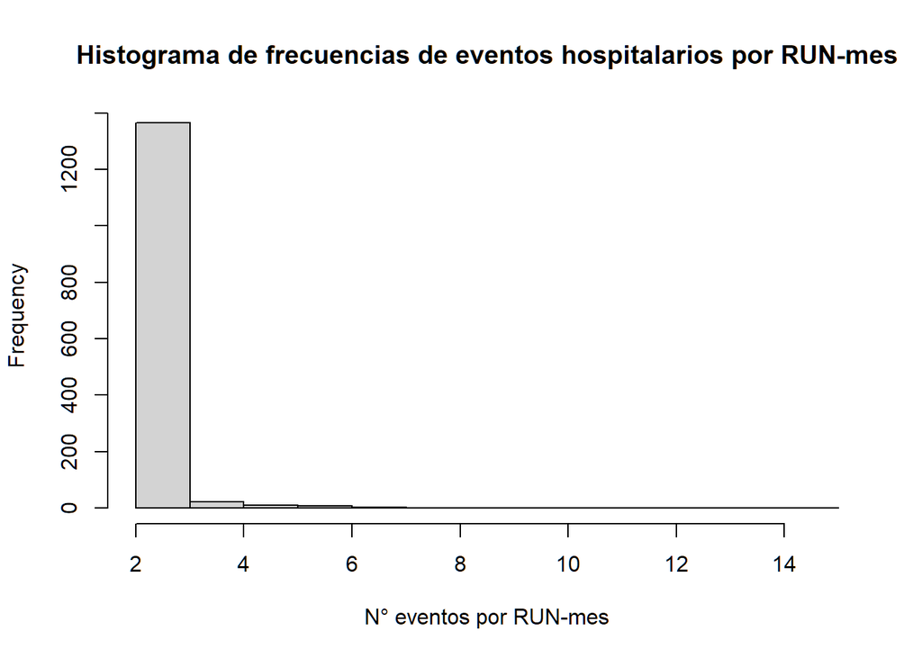

```
Más de un evento hospitalario por RUN-mes, Obs: 3.146
NULL
Más de un evento hospitalario por RUN-mes, RUNs: 1.078
NULL


Table: Caso con la mayor cantidad de eventos hospitalarios por mes

| run| month|factor_inclusivo_real_hist_mas_autperc |glosa_sexo | edad_anos| min_edad_anos| pueblo_originario_01| inclusivo_real_historico|prev_benef_rec_post |cens_time |month_ing2 |month_egr2 |alphabet | sum_autolesiones| days_elapsed|diag1_rec32 |diag2_rec32 |
|---:|-----:|:--------------------------------------|:----------|---------:|-------------:|--------------------:|------------------------:|:-------------------|:---------|:----------|:----------|:--------|----------------:|------------:|:-----------|:-----------|
|   1|     7|00                                     |MUJER      |        16|            15|                    0|                        0|FONASA BC           |52.40     |7.00       |7.10       |psy      |                0|            3|psy         |            |
|   1|     7|00                                     |MUJER      |        16|            15|                    0|                        0|FONASA BC           |52.40     |7.16       |7.39       |psy      |                0|            7|psy         |            |
|   1|     7|00                                     |MUJER      |        16|            15|                    0|                        0|FONASA BC           |52.40     |7.39       |7.43       |psy      |                0|            1|psy         |            |
|   1|     7|00                                     |MUJER      |        16|            15|                    0|                        0|FONASA BC           |52.40     |7.43       |7.46       |psy      |                0|            1|psy         |            |
|   1|     7|00                                     |MUJER      |        16|            15|                    0|                        0|FONASA BC           |52.40     |7.46       |7.49       |psy      |                0|            1|psy         |            |
|   1|     7|00                                     |MUJER      |        16|            15|                    0|                        0|FONASA BC           |52.40     |7.49       |7.59       |psy      |                0|            3|psy         |            |
|   1|     7|00                                     |MUJER      |        16|            15|                    0|                        0|FONASA BC           |52.40     |7.59       |7.62       |psy      |                0|            1|psy         |            |
|   1|     7|00                                     |MUJER      |        16|            15|                    0|                        0|FONASA BC           |52.40     |7.62       |7.66       |psy      |                0|            1|psy         |            |
|   1|     7|00                                     |MUJER      |        16|            15|                    0|                        0|FONASA BC           |52.40     |7.66       |7.69       |psy      |                0|            1|psy         |            |
|   1|     7|00                                     |MUJER      |        16|            15|                    0|                        0|FONASA BC           |52.40     |7.69       |7.72       |psy      |                0|            1|psy         |            |
|   1|     7|00                                     |MUJER      |        16|            15|                    0|                        0|FONASA BC           |52.40     |7.72       |7.82       |psy      |                0|            3|psy         |            |
|   1|     7|00                                     |MUJER      |        16|            15|                    0|                        0|FONASA BC           |52.40     |7.82       |7.85       |psy      |                0|            1|psy         |            |
|   1|     7|00                                     |MUJER      |        16|            15|                    0|                        0|FONASA BC           |52.40     |7.85       |7.89       |psy      |                0|            1|psy         |            |
|   1|     7|00                                     |MUJER      |        16|            15|                    0|                        0|FONASA BC           |52.40     |7.89       |7.92       |psy      |                0|            1|psy         |            |
|   1|     7|00                                     |MUJER      |        16|            15|                    0|                        0|FONASA BC           |52.40     |7.92       |7.95       |psy      |                0|            1|psy         |            |
   Min. 1st Qu.  Median    Mean 3rd Qu.    Max.
   2.00    2.00    2.00    2.23    2.00   15.00
```

```r
#:#:#:#:#:#:#:#:#:#:#:#:#:#:#:#:#:#:#:#:#:#:#:#:#:#:#:#:#:#:#:#:#:#:#:#:#:#:#:#:#:#:
#:#:#:#:#:#:#:#:#:#:#:#:#:#:#:#:#:#:#:#:#:#:#:#:#:#:#:#:#:#:#:#:#:#:#:#:#:#:#:#:#:#:
invisible("Caso con la mayor cantidad de eventos hospitalarios por mes")
ing_calendar_month_t_desde_primera_adm_dup |>
  filter(n_dup==max(n_dup)) |>
  select(run, month, factor_inclusivo_real_hist_mas_autperc, glosa_sexo, edad_anos,
                min_edad_anos, pueblo_originario_01, inclusivo_real_historico, prev_benef_rec_post,
                cens_time, month_ing2, month_egr2, alphabet, sum_autolesiones, days_elapsed, diag1_rec32, diag2_rec32)  |>
  mutate(across(c("cens_time", "month_ing2", "month_egr2"),~sprintf("%1.2f",.))) |>
    (\(df) {
    View(df)
    knitr::kable(mutate(df, run=as.numeric(factor(run))), "markdown", caption= "Caso con la mayor cantidad de eventos hospitalarios por mes") |> print()
    rio::export(df, file="_output/month_dup_max.xlsx")
  })()

invisible("Si interesa mirar en mayor profundidad")
#df_filled2 |> filter(run==ing_calendar_month_t_desde_primera_adm_dup |> filter(n_dup==max(n_dup)) |> distinct(run) |> pull(run)) |> View()

#:#:#:#:#:#:#:#:#:#:#:#:#:#:#:#:#:#:#:#:#:#:#:#:#:#:#:#:#:#:#:#:#:#:#:#:#:#:#:#:#:#:
#:#:#:#:#:#:#:#:#:#:#:#:#:#:#:#:#:#:#:#:#:#:#:#:#:#:#:#:#:#:#:#:#:#:#:#:#:#:#:#:#:#:
ing_calendar_month_t_desde_primera_adm_dup |>
  distinct(run, month, n_dup) %>% pull(n_dup) |>
  (\(df) {
    hist(df, main= "Histograma de frecuencias de eventos hospitalarios por RUN-mes", xlab= "N° eventos por RUN-mes")
    print(summary(df))
  })() # super similar a la base 2024
```

#### 2.2.4. Trimestral

Se replica con la base de datos trimestral.

**Código**

```r
ing_calendar_quarter_t_desde_primera_adm <- janitor::clean_names(sqldf::sqldf("SELECT *
      FROM expand_df_quarter_run_t_desde_primera_adm AS x
      LEFT JOIN dt_df_filled_quarter_t_desde_primera_adm_expand AS y
      ON x.run = y.run
      AND x.quarter = y.quarter
"))
message(paste0("Se añadieron ", formatC(nrow(ing_calendar_quarter_t_desde_primera_adm)-nrow(expand_df_quarter_run_t_desde_primera_adm), big.mark="."), " filas"))
```

```
Se añadieron 2.563 filas
```

**Código**

```r
#:#:#:#:#:#:#:#:#:#:#:#:#:#:#:#:#:#:#:#:#:#:#:#:#:#:#:#:#:#:#:#:#:#:#:#:#:#:#:#:#:#:
#:#:#:#:#:#:#:#:#:#:#:#:#:#:#:#:#:#:#:#:#:#:#:#:#:#:#:#:#:#:#:#:#:#:#:#:#:#:#:#:#:#:

invisible("exploración duplicados")
ing_calendar_quarter_t_desde_primera_adm_dup<-
  as_tidytable(ing_calendar_quarter_t_desde_primera_adm) |>
  select(-run_2) |>  #, fecha_ingreso_rec24_num, fecha_egreso_rec24_num) %>%
  mutate(alphabet= ifelse(is.na(alphabet),"AUS", alphabet)) |>
  arrange(run, quarter) |>
  group_by(run, quarter)  |>
  mutate(n_dup= n()) |>
  ungroup() |>
  filter(n_dup>1) |>
  (\(df) {
    print(cat(paste0("Más de un evento hospitalario por RUN-trim, Obs: ", formatC(nrow(df),big.mark="."), "\n")))
    print(cat(paste0("Más de un evento hospitalario por RUN-trim, RUNs: ", formatC(distinct(df, run)|> nrow(),big.mark="."), "\n")))
    df
  })()
```

**Código**

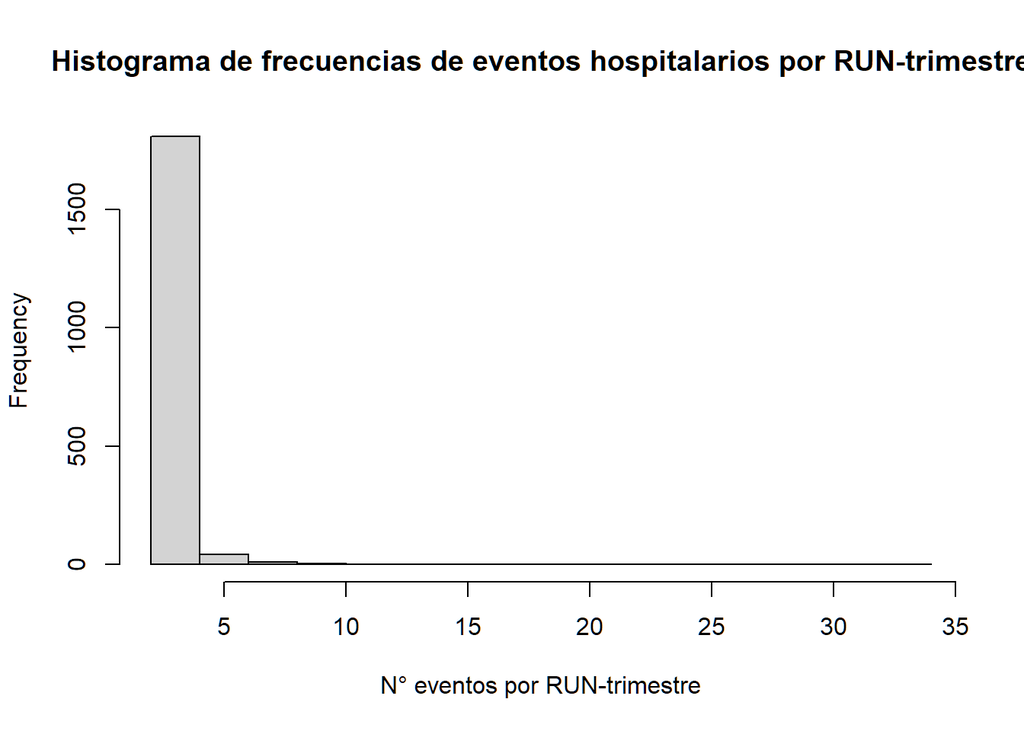

```
Más de un evento hospitalario por RUN-trim, Obs: 4.427
NULL
Más de un evento hospitalario por RUN-trim, RUNs: 1.468
NULL


Table: Caso con la mayor cantidad de eventos hospitalarios por trimestre

| run| quarter|factor_inclusivo_real_hist_mas_autperc |glosa_sexo | edad_anos| min_edad_anos| pueblo_originario_01| inclusivo_real_historico|prev_benef_rec_post |cens_time |quarter_ing2 |quarter_egr2 |alphabet | sum_autolesiones| days_elapsed|diag1_rec32 |diag2_rec32 |
|---:|-------:|:--------------------------------------|:----------|---------:|-------------:|--------------------:|------------------------:|:-------------------|:---------|:------------|:------------|:--------|----------------:|------------:|:-----------|:-----------|
|   1|       2|00                                     |MUJER      |        15|            15|                    0|                        0|FONASA BC           |17.47     |1.92         |2.06         |psy      |                0|           13|psy         |            |
|   1|       2|00                                     |MUJER      |        15|            15|                    0|                        0|FONASA BC           |17.47     |2.22         |2.27         |psy      |                0|            4|psy         |            |
|   1|       2|00                                     |MUJER      |        16|            15|                    0|                        0|FONASA BC           |17.47     |2.06         |2.12         |psy      |                0|            6|psy         |            |
|   1|       2|00                                     |MUJER      |        16|            15|                    0|                        0|FONASA BC           |17.47     |2.14         |2.20         |psy      |                0|            6|psy         |            |
|   1|       2|00                                     |MUJER      |        16|            15|                    0|                        0|FONASA BC           |17.47     |2.27         |2.30         |psy      |                0|            3|psy         |            |
|   1|       2|00                                     |MUJER      |        16|            15|                    0|                        0|FONASA BC           |17.47     |2.31         |2.31         |psy      |                0|            0|psy         |            |
|   1|       2|00                                     |MUJER      |        16|            15|                    0|                        0|FONASA BC           |17.47     |2.32         |2.32         |psy      |                0|            0|psy         |            |
|   1|       2|00                                     |MUJER      |        16|            15|                    0|                        0|FONASA BC           |17.47     |2.33         |2.37         |psy      |                0|            3|psy         |            |
|   1|       2|00                                     |MUJER      |        16|            15|                    0|                        0|FONASA BC           |17.47     |2.39         |2.46         |psy      |                0|            7|psy         |            |
|   1|       2|00                                     |MUJER      |        16|            15|                    0|                        0|FONASA BC           |17.47     |2.46         |2.48         |psy      |                0|            1|psy         |            |
```

[output cut: 26 more lines]

```r
#:#:#:#:#:#:#:#:#:#:#:#:#:#:#:#:#:#:#:#:#:#:#:#:#:#:#:#:#:#:#:#:#:#:#:#:#:#:#:#:#:#:
#:#:#:#:#:#:#:#:#:#:#:#:#:#:#:#:#:#:#:#:#:#:#:#:#:#:#:#:#:#:#:#:#:#:#:#:#:#:#:#:#:#:
invisible("Caso con la mayor cantidad de eventos hospitalarios por mes")
ing_calendar_quarter_t_desde_primera_adm_dup |>
  filter(n_dup==max(n_dup)) |>
  select(run, quarter, factor_inclusivo_real_hist_mas_autperc, glosa_sexo, edad_anos,
                min_edad_anos, pueblo_originario_01, inclusivo_real_historico, prev_benef_rec_post,
                cens_time, quarter_ing2, quarter_egr2, alphabet, sum_autolesiones, days_elapsed, diag1_rec32, diag2_rec32)|>
  mutate(across(c("cens_time", "quarter_ing2", "quarter_egr2"),~sprintf("%1.2f",.))) |>
    (\(df) {
    View(df)
    knitr::kable(mutate(df, run=as.numeric(factor(run))), "markdown", caption= "Caso con la mayor cantidad de eventos hospitalarios por trimestre") |> print()
    rio::export(df, file="_output/quarter_dup_max.xlsx")
  })()

invisible("Si interesa mirar en mayor profundidad")
#df_filled2 |> filter(run==ing_calendar_quarter_t_desde_primera_adm_dup |> filter(n_dup==max(n_dup)) |> distinct(run) |> pull(run)) |> View()

#:#:#:#:#:#:#:#:#:#:#:#:#:#:#:#:#:#:#:#:#:#:#:#:#:#:#:#:#:#:#:#:#:#:#:#:#:#:#:#:#:#:
#:#:#:#:#:#:#:#:#:#:#:#:#:#:#:#:#:#:#:#:#:#:#:#:#:#:#:#:#:#:#:#:#:#:#:#:#:#:#:#:#:#:
ing_calendar_quarter_t_desde_primera_adm_dup|>
  distinct(run, quarter, n_dup) %>% pull(n_dup)|>
  (\(df) {
    hist(df, main= "Histograma de frecuencias de eventos hospitalarios por RUN-trimestre", xlab= "N° eventos por RUN-trimestre")
    print(summary(df))
  })() # super similar a la base 2024
```

### 2.2.5. Agrupación de eventos para definir una estructura RUN-tiempo 1:1

Definimos la base de datos `dt_ing_calendar_month_t_desde_primera_adm` (en formato data.table) para llevar a cabo de manera eficiente la suma de alfabetos por cada paciente. Suma cada evento siempre run_2 se encuentre disponible (hubiese unión del esqueleto con datos reales) para esa combinación RUN-mes.

Posteriormente,

  . `delta_comb`= concatenar delta
  - `n_dup`= número de eventos por cada combinación RUN-mes
  - `min_edad_anos`= edad más antigua en años
  - `pueblo_originario_01`= pueblo originario binario (0/1=reporta) fuente MINSAL
  - `inclusivo_real_historico`= si un paciente posee registros MINSAL desde 2005 o por el registro social de hogares o CONADI (binario, no diferencia)
  - `prev_benef_rec_post`= combinación de previsión y tramo (posterior a retroalimentación)
  - `glosa_sexo`= sexo
  - `factor_inclusivo_real_hist_mas_autperc`= variable que diferencia reportes a MINSAL históricos o registro social de hogares y CONADI (tres opciones)
  - `cens_time`= Promedio del tiempo desde la primera admisión a la censura (como es invariante a pacientes, debiese ser el mismo)
  - `death_time`= Promedio del tiempo desde la primera admisión al fallecimiento (como es invariante a pacientes, debiese ser el mismo)
  - `codigo_region_rec_base`= RM vs. no-RM de la primera hospitalización del 2018
  - `estab_homo_base`= Código establecimiento de la primera hospitalización del 2018
  - `sum_autolesiones`= Suma de diagnósticos de autolesiones para cada combinación RUN-mes
  - `sum_codigo_region_rec_rm`= Suma de atenciones en RM en cada RUN-mes
  - `sum_codigo_region_rec_norm`= Suma de atenciones en no-RM en cada RUN-mes
- Ya sin agrupar, para cada fila, generar las siguientes variables (rowwise)
  - `alphabet2`= Alfabeto para diagnósticos TSM y TUS: COC-MAR-OH-PSU-CP-CP_PSU. Si no hay eventos observados, se codifica como AUS. Si este último no es el caso, queda codificado como OTRO
  - `alphabet3`= Simplificación al 2024-08-09 de `alphabet2` en SUS-CP-PSI-AUS-OTRO
  - `alphabet4`= Para región (2024-08-09) no-RM/AUS/RM

**Código**

```r
gc()

# dt_ing_calendar_month_t_desde_primera_adm <- data.table::as.data.table(ing_calendar_month_t_desde_primera_adm)

# dt_ing_calendar_month_t_desde_primera_adm[, `:=`(
#   sum_tus2 = ifelse(!is.na(run_2) & run_2 != "", sum(.SD %in% c("coc", "mar", "oh"), na.rm = TRUE), NA_integer_),
#   sum_coc2 = ifelse(!is.na(run_2) & run_2 != "", sum(.SD %in% c("coc"), na.rm = TRUE), NA_integer_),
#   sum_mar2 = ifelse(!is.na(run_2) & run_2 != "", sum(.SD %in% c("mar"), na.rm = TRUE), NA_integer_),
#   sum_oh2 = ifelse(!is.na(run_2) & run_2 != "", sum(.SD %in% c("oh"), na.rm = TRUE), NA_integer_),
#   sum_tus_psy2 = ifelse(!is.na(run_2) & run_2 != "", sum(.SD %in% c("coc", "mar", "oh", "psy"), na.rm = TRUE), NA_integer_)
# ), by = 1:nrow(dt_ing_calendar_month_t_desde_primera_adm), .SDcols = patterns("rec32")]

dt_ing_calendar_month_t_desde_primera_adm <- as_tidytable(ing_calendar_month_t_desde_primera_adm)|>
  mutate_rowwise(
    sum_tus2 = if_else(
      !is.na(run_2) & run_2 != "",
      sum(c_across(matches("rec32")) %in% c("coc", "mar", "oh"), na.rm = TRUE),
      NA_integer_
    ),
    sum_coc2 = if_else(
      !is.na(run_2) & run_2 != "",
      sum(c_across(matches("rec32")) %in% c("coc"), na.rm = TRUE),
      NA_integer_
    ),
    sum_mar2 = if_else(
      !is.na(run_2) & run_2 != "",
      sum(c_across(matches("rec32")) %in% c("mar"), na.rm = TRUE),
      NA_integer_
    ),
    sum_oh2 = if_else(
      !is.na(run_2) & run_2 != "",
      sum(c_across(matches("rec32")) %in% c("oh"), na.rm = TRUE),
      NA_integer_
    ),
    sum_tus_psy2 = if_else(
      !is.na(run_2) & run_2 != "",
      sum(c_across(matches("rec32")) %in% c("coc", "mar", "oh", "psy"), na.rm = TRUE),
      NA_integer_
    )
  )


#:#:#:#:#:#:#:#:#:#:#:#:#:#:#:#:#:#:#:#:#:#:#:#:#:#:#:#:#:#:#:#:#:#:#:#:#:#:#:#:#:#:
#:#:#:#:#:#:#:#:#:#:#:#:#:#:#:#:#:#:#:#:#:#:#:#:#:#:#:#:#:#:#:#:#:#:#:#:#:#:#:#:#:#:
#:#:#:#:#:#:#:#:#:#:#:#:#:#:#:#:#:#:#:#:#:#:#:#:#:#:#:#:#:#:#:#:#:#:#:#:#:#:#:#:#:#:

dt_ing_calendar_month_t_desde_primera_adm_dedup<-
  dt_ing_calendar_month_t_desde_primera_adm |>
  mutate(delta= round((((days_elapsed)+1)/30.436875)*100,1))|>
  mutate(codigo_region_rec=ifelse(codigo_region==13,"RM","noRM"))|>
  mutate(estab_homo=as.character(estab_homo)) |>
  group_by(run) |>
  mutate(
    min_edad_anos                          = mean(min_edad_anos, na.rm = TRUE),
    pueblo_originario_01                   = first(pueblo_originario_01, na_rm = TRUE),# el argumento no fue usado (na.rm = TRUE) #data.table::
    inclusivo_real_historico               = max(inclusivo_real_historico, na.rm = TRUE),
    prev_benef_rec_post                    = max(prev_benef_rec_post, na.rm = TRUE),
    glosa_sexo                             = max(glosa_sexo, na.rm = TRUE),
    factor_inclusivo_real_hist_mas_autperc = max(factor_inclusivo_real_hist_mas_autperc, na.rm = TRUE),
    cens_time                              = mean(cens_time, na.rm=T),
    death_time                             = mean(death_time, na.rm=T),
    codigo_region_rec_base                 = first(codigo_region_rec, na_rm=T), #data.table::
    estab_homo_base                        = first(estab_homo, na_rm=T) #data.table::
  )|>
  ungroup()|>
  group_by(run, month)|>
  summarise(
    sum_tus2      = sum(sum_tus2, na.rm = TRUE),
    sum_coc2      = sum(sum_coc2, na.rm = TRUE),
    sum_mar2      = sum(sum_mar2, na.rm = TRUE),
    sum_oh2       = sum(sum_oh2, na.rm = TRUE),
    sum_tus_psy2  = sum(sum_tus_psy2, na.rm = TRUE),
    alphabet_comb = paste(alphabet, collapse = " + "),
    delta_comb    = paste(delta, collapse = " + "),
    n_dup         = n(),
    min_edad_anos             = mean(min_edad_anos, na.rm = TRUE),
    pueblo_originario_01      = first(pueblo_originario_01, na_rm = TRUE),#data.table::
    inclusivo_real_historico  = max(inclusivo_real_historico, na.rm = TRUE),
    prev_benef_rec_post       = max(prev_benef_rec_post, na.rm = TRUE),
    glosa_sexo                             = max(glosa_sexo, na.rm = TRUE),
    factor_inclusivo_real_hist_mas_autperc = max(factor_inclusivo_real_hist_mas_autperc, na.rm = TRUE),
    cens_time                              = mean(cens_time, na.rm=T),
    death_time                             = mean(death_time, na.rm=T),
    codigo_region_rec_base                 = first(codigo_region_rec, na_rm=T),#data.table::
    estab_homo_base                        = first(estab_homo, na_rm=T),#data.table::
    sum_autolesiones                       = sum(sum_autolesiones, na.rm=T),
    sum_codigo_region_rec_rm               = sum(codigo_region_rec=="RM", na.rm=T),
    sum_codigo_region_rec_norm             = sum(codigo_region_rec=="noRM", na.rm=T),
    mort_intrahosp                         = sum(cond_egr==2, na.rm=T)
  ) |>
  ungroup() |>
  mutate(alphabet2 = case_when(
    sum_coc2 > 0 & sum_coc2 == sum_tus2 & sum_tus2 == sum_tus_psy2 ~ "coc",
    sum_mar2 > 0 & sum_mar2 == sum_tus2 & sum_tus2 == sum_tus_psy2 ~ "mar",
    sum_oh2 > 0 & sum_oh2 == sum_tus2 & sum_tus2 == sum_tus_psy2 ~ "oh",
    ((sum_coc2 > 0) + (sum_mar2 > 0) + (sum_oh2 > 0)) > 1 & sum_tus2 == sum_tus_psy2 ~ "psu",
    ((sum_coc2 > 0) + (sum_mar2 > 0) + (sum_oh2 > 0)) == 1 & sum_tus_psy2 > sum_tus2 ~ "cp",
    ((sum_coc2 > 0) + (sum_mar2 > 0) + (sum_oh2 > 0)) > 1 & sum_tus_psy2 > sum_tus2 ~ "cp_psu",
    sum_tus_psy2 > 0 & sum_tus2 == 0 ~ "psy",
    alphabet_comb=="NA"~"aus",
    TRUE ~ "otro"
  ))|>
  #2024-08-09: modificaron los estados del alfabeto
  mutate(alphabet3 = case_when(
    ((sum_coc2 > 0) + (sum_mar2 > 0) + (sum_oh2 > 0)) >= 1 & sum_tus_psy2 == sum_tus2 ~ "sus",
    ((sum_coc2 > 0) + (sum_mar2 > 0) + (sum_oh2 > 0)) >= 1 & sum_tus_psy2 > sum_tus2 ~ "cp",
    sum_tus_psy2 > 0 & sum_tus2 == 0 ~ "psi",
    alphabet_comb=="NA"~"aus",
    TRUE ~ "otro"
  ))|>
  #2024-08-09: para región
  mutate(alphabet4 = case_when(
    sum_codigo_region_rec_norm>0~ "noRM",
    alphabet_comb=="NA"~"aus",
    TRUE ~ "RM"
  ))|>
  #2024-08-10: corregir por ausencias del primer establecimiento en región y código
  group_by(run)|>
  mutate(codigo_region_rec_base= max(codigo_region_rec_base, na.rm=T),
                estab_homo_base= max(estab_homo_base, na.rm=T)) |>
  ungroup()|>
  #codigo_region_rec_base
  mutate(alphabet_comb= ifelse(alphabet_comb=="NA",NA, alphabet_comb),
                delta_comb= ifelse(delta_comb=="NA",NA, delta_comb)) |>
      (\(df) {
    print(cat(paste0("Despues de agrupación por cada grilla-tiempo desde primera adm., Obs: ", formatC(nrow(df),big.mark="."), "\n")))
    print(cat(paste0("Despues de agrupación por cada grilla-tiempo desde primera adm., RUNs: ", formatC(distinct(df, run)|> nrow(),big.mark="."), "\n")))
    df
  })()
```

```
             used    (Mb) gc trigger    (Mb)   max used    (Mb)
Ncells   13076182   698.4   26401490  1410.0   26401490  1410.0
Vcells 3275833398 24992.7 5468153679 41718.8 4171205205 31823.8
Despues de agrupación por cada grilla-tiempo desde primera adm., Obs: 397.560
NULL
Despues de agrupación por cada grilla-tiempo desde primera adm., RUNs: 6.626
NULL
```

Comprobamos que exista la cantidad de RUN-meses esperable.

**Código**

```r
if(nrow(dt_ing_calendar_month_t_desde_primera_adm_dedup)> length(unique(dt_ing_calendar_month_t_desde_primera_adm$run))*60){
  stop(paste0("Número de filas, debería ser: ",
              length(unique(dt_ing_calendar_month_t_desde_primera_adm$run))*60))
}
if(
dt_ing_calendar_month_t_desde_primera_adm_dedup |> group_by(run) |> summarise(sum_cond_egr= sum(mort_intrahosp, na.rm=T)) |> filter(sum_cond_egr>1) |> nrow()>0){warning("Más de un fallecimiento por usuario")}
```

Ahora hacemos lo mismo para la base por trimestre

**Código**

```r
gc()

dt_ing_calendar_quarter_t_desde_primera_adm <- as_tidytable(ing_calendar_quarter_t_desde_primera_adm) |>
  mutate_rowwise(
    sum_tus2 = if_else(
      !is.na(run_2) & run_2 != "",
      sum(c_across(matches("rec32")) %in% c("coc", "mar", "oh"), na.rm = TRUE),
      NA_integer_
    ),
    sum_coc2 = if_else(
      !is.na(run_2) & run_2 != "",
      sum(c_across(matches("rec32")) %in% c("coc"), na.rm = TRUE),
      NA_integer_
    ),
    sum_mar2 = if_else(
      !is.na(run_2) & run_2 != "",
      sum(c_across(matches("rec32")) %in% c("mar"), na.rm = TRUE),
      NA_integer_
    ),
    sum_oh2 = if_else(
      !is.na(run_2) & run_2 != "",
      sum(c_across(matches("rec32")) %in% c("oh"), na.rm = TRUE),
      NA_integer_
    ),
    sum_tus_psy2 = if_else(
      !is.na(run_2) & run_2 != "",
      sum(c_across(matches("rec32")) %in% c("coc", "mar", "oh", "psy"), na.rm = TRUE),
      NA_integer_
    )
  )

# dt_ing_calendar_quarter_t_desde_primera_adm <- data.table::as.data.table(ing_calendar_quarter_t_desde_primera_adm)
#
# dt_ing_calendar_quarter_t_desde_primera_adm[, `:=`(
#   sum_tus2 = ifelse(!is.na(run_2) & run_2 != "", sum(.SD %in% c("coc", "mar", "oh"), na.rm = TRUE), NA_integer_),
#   sum_coc2 = ifelse(!is.na(run_2) & run_2 != "", sum(.SD %in% c("coc"), na.rm = TRUE), NA_integer_),
#   sum_mar2 = ifelse(!is.na(run_2) & run_2 != "", sum(.SD %in% c("mar"), na.rm = TRUE), NA_integer_),
#   sum_oh2 = ifelse(!is.na(run_2) & run_2 != "", sum(.SD %in% c("oh"), na.rm = TRUE), NA_integer_),
#   sum_tus_psy2 = ifelse(!is.na(run_2) & run_2 != "", sum(.SD %in% c("coc", "mar", "oh", "psy"), na.rm = TRUE), NA_integer_)
# ), by = 1:nrow(dt_ing_calendar_quarter_t_desde_primera_adm), .SDcols = patterns("rec32")]


#:#:#:#:#:#:#:#:#:#:#:#:#:#:#:#:#:#:#:#:#:#:#:#:#:#:#:#:#:#:#:#:#:#:#:#:#:#:#:#:#:#:
#:#:#:#:#:#:#:#:#:#:#:#:#:#:#:#:#:#:#:#:#:#:#:#:#:#:#:#:#:#:#:#:#:#:#:#:#:#:#:#:#:#:
#:#:#:#:#:#:#:#:#:#:#:#:#:#:#:#:#:#:#:#:#:#:#:#:#:#:#:#:#:#:#:#:#:#:#:#:#:#:#:#:#:#:

dt_ing_calendar_quarter_t_desde_primera_adm_dedup<-
  dt_ing_calendar_quarter_t_desde_primera_adm |>
  mutate(delta= round((((days_elapsed)+1)/91.31063)*100,1))|>
  mutate(codigo_region_rec=ifelse(codigo_region==13,"RM","noRM"))|>
  group_by(run)|>
  mutate(
    min_edad_anos                          = mean(min_edad_anos, na.rm = TRUE),
    pueblo_originario_01                   = first(pueblo_originario_01, na_rm = TRUE),#data.table::
    inclusivo_real_historico               = max(inclusivo_real_historico, na.rm = TRUE),
    prev_benef_rec_post                    = max(prev_benef_rec_post, na.rm = TRUE),
    glosa_sexo                             = max(glosa_sexo, na.rm = TRUE),
    factor_inclusivo_real_hist_mas_autperc = max(factor_inclusivo_real_hist_mas_autperc, na.rm = TRUE),
    cens_time                              = mean(cens_time, na.rm=T),
    death_time                             = mean(death_time, na.rm=T),
    codigo_region_rec_base                 = first(codigo_region_rec, na_rm=T),#data.table::
    estab_homo_base                        = first(estab_homo, na_rm=T)#data.table::
  )|>
  ungroup()|>
  group_by(run, quarter)|>
  summarise(
    sum_tus2      = sum(sum_tus2, na.rm = TRUE),
    sum_coc2      = sum(sum_coc2, na.rm = TRUE),
    sum_mar2      = sum(sum_mar2, na.rm = TRUE),
    sum_oh2       = sum(sum_oh2, na.rm = TRUE),
    sum_tus_psy2  = sum(sum_tus_psy2, na.rm = TRUE),
    alphabet_comb = paste(alphabet, collapse = " + "),
    delta_comb    = paste(delta, collapse = " + "),
    n_dup         = n(),
    min_edad_anos             = mean(min_edad_anos, na.rm = TRUE),
    pueblo_originario_01      = first(pueblo_originario_01, na_rm = TRUE),#data.table::
    inclusivo_real_historico  = max(inclusivo_real_historico, na.rm = TRUE),
    prev_benef_rec_post       = max(prev_benef_rec_post, na.rm = TRUE),
    glosa_sexo                             = max(glosa_sexo, na.rm = TRUE),
    factor_inclusivo_real_hist_mas_autperc = max(factor_inclusivo_real_hist_mas_autperc, na.rm = TRUE),
    cens_time                              = mean(cens_time, na.rm=T),
    death_time                             = mean(death_time, na.rm=T),
    codigo_region_rec_base                 = first(codigo_region_rec, na_rm=T),#data.table::
    estab_homo_base                        = first(estab_homo, na_rm=T),    #data.table::
    sum_autolesiones                       = sum(sum_autolesiones, na.rm=T),
    sum_codigo_region_rec_rm               = sum(codigo_region_rec=="RM", na.rm=T),
    sum_codigo_region_rec_norm             = sum(codigo_region_rec=="noRM", na.rm=T),
    mort_intrahosp                         = sum(cond_egr==2, na.rm=T)
  )|>
  ungroup()|>
  mutate(alphabet2 = case_when(
    sum_coc2 > 0 & sum_coc2 == sum_tus2 & sum_tus2 == sum_tus_psy2 ~ "coc",
    sum_mar2 > 0 & sum_mar2 == sum_tus2 & sum_tus2 == sum_tus_psy2 ~ "mar",
    sum_oh2 > 0 & sum_oh2 == sum_tus2 & sum_tus2 == sum_tus_psy2 ~ "oh",
    ((sum_coc2 > 0) + (sum_mar2 > 0) + (sum_oh2 > 0)) > 1 & sum_tus2 == sum_tus_psy2 ~ "psu",
    ((sum_coc2 > 0) + (sum_mar2 > 0) + (sum_oh2 > 0)) == 1 & sum_tus_psy2 > sum_tus2 ~ "cp",
    ((sum_coc2 > 0) + (sum_mar2 > 0) + (sum_oh2 > 0)) > 1 & sum_tus_psy2 > sum_tus2 ~ "cp_psu",
    sum_tus_psy2 > 0 & sum_tus2 == 0 ~ "psy",
    alphabet_comb=="NA"~"aus",
    TRUE ~ "otro"
  ))|>
  #2024-08-09: modificaron los estados del alfabeto
  mutate(alphabet3 = case_when(
    ((sum_coc2 > 0) + (sum_mar2 > 0) + (sum_oh2 > 0)) >= 1 & sum_tus_psy2 == sum_tus2 ~ "sus",
    ((sum_coc2 > 0) + (sum_mar2 > 0) + (sum_oh2 > 0)) >= 1 & sum_tus_psy2 > sum_tus2 ~ "cp",
    sum_tus_psy2 > 0 & sum_tus2 == 0 ~ "psi",
    alphabet_comb=="NA"~"aus",
    TRUE ~ "otro"
  ))|>
  #2024-08-09: para región
  mutate(alphabet4 = case_when(
    sum_codigo_region_rec_norm>0~ "noRM",
    alphabet_comb=="NA"~"aus",
    TRUE ~ "RM"
  ))|>
  #2024-08-10: corregir por ausencias del primer establecimiento en región y código
  group_by(run)|>
  mutate(codigo_region_rec_base= max(codigo_region_rec_base, na.rm=T),
                estab_homo_base= max(estab_homo_base, na.rm=T))|>
  ungroup()|>
  mutate(alphabet_comb= ifelse(alphabet_comb=="NA",NA, alphabet_comb),
                delta_comb= ifelse(delta_comb=="NA",NA, delta_comb))
#Despues de agrupación por cada grilla-tiempo desde primera adm., Obs: 397.560
#Despues de agrupación por cada grilla-tiempo desde primera adm., RUNs: 6.626
```

```
             used    (Mb) gc trigger    (Mb)   max used    (Mb)
Ncells   13076009   698.4   26401490  1410.0   26401490  1410.0
Vcells 3285109868 25063.4 5468153679 41718.8 4171205205 31823.8
```

**Código**

```r
invisible("Ver si se añaden filas RUN*20")
if(nrow(dt_ing_calendar_quarter_t_desde_primera_adm_dedup)> length(unique(dt_ing_calendar_quarter_t_desde_primera_adm$run))*20){
  stop(paste0("Número de filas, debería ser: ",
              length(unique(dt_ing_calendar_quarter_t_desde_primera_adm$run))*20))
}

invisible("Ver si los")
if(
dt_ing_calendar_quarter_t_desde_primera_adm_dedup |> group_by(run) |> summarise(sum_cond_egr= sum(mort_intrahosp, na.rm=T)) |> filter(sum_cond_egr>1) |> nrow()>0){warning("Más de un fallecimiento por usuario")}

if(
dt_ing_calendar_quarter_t_desde_primera_adm_dedup |> group_by(run) |> summarise(sum_cond_egr= sum(mort_intrahosp, na.rm=T)) |> filter(sum_cond_egr>0) |> nrow()>0){warning("Al menos un fallecimiento por usuario")}
```

## 2.3. Retoques y modificaciones finales

### 2.3.1. Formato ancho

#### 2.3.1.a. Mensual

##### 2.3.1.a.I. Alfabeto TSM/TUS complejo

El análisis de secuencias requiere contar con una base de datos en formato ancho. Por lo mismo, se llevo a cabo el formateo de la base de datos.

Luego,

- Generamos una base alternativa que incluya los estados de censura, para fines descriptivos (`ing_dt_ing_calendar_month_t_desde_primera_adm_dedup_wide_cens`).
- Recodificamos la variable `death_time`, para que en caso que las personas que no experimenten fallecimiento, reciban el recuento máximo de meses/trimestres; de lo contrario, que indique los meses/trimestres desde la primera admisión en que se registró el fallecimiento.
- Comprobamos que no hubiera diferencias entre el tiempo entre la censura y los pacientes con mortalidad intrahospitalaria.
- Para la base de datos censurada `ing_dt_ing_calendar_month_t_desde_primera_adm_dedup_wide_cens`, ya que fui introduciendo el estado “cens”, ya fuera por fallecimiento o censura. Esto lo va introduciendo de manera recursiva, desde la columna 59 hasta la 1 (asumimos que en el tiempo 0 las personas se encontraban, de lo contrario no podríamos haberlas incorporado a la base).

**Código**

```r
ing_dt_ing_calendar_month_t_desde_primera_adm_dedup_wide<-
dt_ing_calendar_month_t_desde_primera_adm_dedup|>
  pivot_wider(id_cols= c("run","pueblo_originario_01", "glosa_sexo", "factor_inclusivo_real_hist_mas_autperc", "inclusivo_real_historico",  "prev_benef_rec_post", "cens_time", "death_time","codigo_region_rec_base", "estab_homo_base"),#,
  names_from="month", values_from ="alphabet2") #%>%

if(
  ( ing_dt_ing_calendar_month_t_desde_primera_adm_dedup_wide |>
    filter(`0`=="otro") |> pull(run) |> length() ) >0
){
  otro_primer_tto<- ing_dt_ing_calendar_month_t_desde_primera_adm_dedup_wide |>
    filter(`0`=="otro") |> pull(run)
  stop("hay un usuario con tratamiento Otro como el primero")
  } #78c5ddad6b22f96cbb140914ecda8a0a2bc577655ab0fa0d4882cf24b2d9308d

#:#:#:#:#:#:#:#:#:#:#:#:#:#:#:#:#:#:#:#:#:#:#:#:#:#:#:#:#:#:#:#:#:#:#:#:#:#:#:#:
#:#:#:#:#:#:#:#:#:#:#:#:#:#:#:#:#:#:#:#:#:#:#:#:#:#:#:#:#:#:#:#:#:#:#:#:#:#:#:#:

invisible("Se añadió una base de datos con censura")
ing_dt_ing_calendar_month_t_desde_primera_adm_dedup_wide_cens <-
  ing_dt_ing_calendar_month_t_desde_primera_adm_dedup_wide

#:#:#:#:#:#:#:#:#:#:#:#:#:#:#:#:#:#:#:#:#:#:#:#:#:#:#:#:#:#:#:#:#:#:#:#:#:#:#:#:
#:#:#:#:#:#:#:#:#:#:#:#:#:#:#:#:#:#:#:#:#:#:#:#:#:#:#:#:#:#:#:#:#:#:#:#:#:#:#:#:

invisible("Se añade el tiempo al fallecimiento")
ing_dt_ing_calendar_month_t_desde_primera_adm_dedup_wide$death_time<-
  ifelse(is.nan(ing_dt_ing_calendar_month_t_desde_primera_adm_dedup_wide$death_time), 60, ing_dt_ing_calendar_month_t_desde_primera_adm_dedup_wide$death_time)

ing_dt_ing_calendar_month_t_desde_primera_adm_dedup_wide_cens$death_time<-
  ifelse(is.nan(ing_dt_ing_calendar_month_t_desde_primera_adm_dedup_wide_cens$death_time), 60, ing_dt_ing_calendar_month_t_desde_primera_adm_dedup_wide_cens$death_time)

#:#:#:#:#:#:#:#:#:#:#:#:#:#:#:#:#:#:#:#:#:#:#:#:#:#:#:#:#:#:#:#:#:#:#:#:#:#:#:#:
#:#:#:#:#:#:#:#:#:#:#:#:#:#:#:#:#:#:#:#:#:#:#:#:#:#:#:#:#:#:#:#:#:#:#:#:#:#:#:#:

invisible("Comprobar que no haya personas que no murieran")
run_mort_intrahosp<-
dt_ing_calendar_month_t_desde_primera_adm_dedup |> group_by(run) |> summarise(sum_cond_egr= sum(mort_intrahosp, na.rm=T)) |> filter(sum_cond_egr>0) |> pull(run)

if(
  ( ing_dt_ing_calendar_month_t_desde_primera_adm_dedup_wide |>
  filter(run %in% run_mort_intrahosp, death_time==60) |>
  nrow()
  ) >0
  ){
    stop("Hay pacientes con mortalidad intrahospitalaria que no aparecen en las ases de mortalidad")
    }

if(
  ( ing_dt_ing_calendar_month_t_desde_primera_adm_dedup_wide |>
    filter(`0`=="otro") |> pull(run) |> length() ) >0
){
  otro_primer_tto<- ing_dt_ing_calendar_month_t_desde_primera_adm_dedup_wide |>
    filter(`0`=="otro") |> pull(run)
  stop("hay un usuario con tratamiento Otro como el primero")

  } #78c5ddad6b22f96cbb140914ecda8a0a2bc577655ab0fa0d4882cf24b2d9308d

#:#:#:#:#:#:#:#:#:#:#:#:#:#:#:#:#:#:#:#:#:#:#:#:#:#:#:#:#:#:#:#:#:#:#:#:#:#:#:#:
#:#:#:#:#:#:#:#:#:#:#:#:#:#:#:#:#:#:#:#:#:#:#:#:#:#:#:#:#:#:#:#:#:#:#:#:#:#:#:#:

#tiene censura 59, si la cur_column es mayor o igual a la columna 59, "censura"
for(i in 59:1) {
  ing_dt_ing_calendar_month_t_desde_primera_adm_dedup_wide_cens <- ing_dt_ing_calendar_month_t_desde_primera_adm_dedup_wide_cens %>%
    mutate(!!as.character(i) := ifelse(ceiling(cens_time) <= i, "cens", !!sym(as.character(i))))
}
for(i in 59:1) {
  ing_dt_ing_calendar_month_t_desde_primera_adm_dedup_wide_cens <- ing_dt_ing_calendar_month_t_desde_primera_adm_dedup_wide_cens %>%
    mutate(!!as.character(i) := ifelse(ceiling(death_time) <= i, "cens", !!sym(as.character(i))))
}
```

##### 2.3.1.a.II. Alfabeto TSM/TUS simplificado

Esta base se denominó `ing_dt_ing_calendar_month_t_desde_primera_adm_dedup_wide2`

**Código**

```r
#2024-08-09: modificaron los estados del alfabeto
ing_dt_ing_calendar_month_t_desde_primera_adm_dedup_wide2<-
  dt_ing_calendar_month_t_desde_primera_adm_dedup |>
  pivot_wider(id_cols= c("run","pueblo_originario_01", "glosa_sexo",
                                "factor_inclusivo_real_hist_mas_autperc", "inclusivo_real_historico",
                                "prev_benef_rec_post", "cens_time", "death_time",
                                "codigo_region_rec_base", "estab_homo_base"),
                     names_from="month", values_from ="alphabet3") #%>%

#table(ing_dt_ing_calendar_month_t_desde_primera_adm_dedup_wide2$`0`, exclude=NULL)


if(
  ( ing_dt_ing_calendar_month_t_desde_primera_adm_dedup_wide2 |>
    filter(`0`=="otro") |> pull(run) |> length() ) >0
){
  otro_primer_tto<- ing_dt_ing_calendar_month_t_desde_primera_adm_dedup_wide2 |>
    filter(`0`=="otro") |> pull(run)
  stop("hay un usuario con tratamiento Otro como el primero")
  } #78c5ddad6b22f96cbb140914ecda8a0a2bc577655ab0fa0d4882cf24b2d9308d

#:#:#:#:#:#:#:#:#:#:#:#:#:#:#:#:#:#:#:#:#:#:#:#:#:#:#:#:#:#:#:#:#:#:#:#:#:#:#:#:
#:#:#:#:#:#:#:#:#:#:#:#:#:#:#:#:#:#:#:#:#:#:#:#:#:#:#:#:#:#:#:#:#:#:#:#:#:#:#:#:

invisible("Se añadió una base de datos con censura")
ing_dt_ing_calendar_month_t_desde_primera_adm_dedup_wide2_cens <-
  ing_dt_ing_calendar_month_t_desde_primera_adm_dedup_wide2

#:#:#:#:#:#:#:#:#:#:#:#:#:#:#:#:#:#:#:#:#:#:#:#:#:#:#:#:#:#:#:#:#:#:#:#:#:#:#:#:
#:#:#:#:#:#:#:#:#:#:#:#:#:#:#:#:#:#:#:#:#:#:#:#:#:#:#:#:#:#:#:#:#:#:#:#:#:#:#:#:

invisible("Se añade el tiempo al fallecimiento")
ing_dt_ing_calendar_month_t_desde_primera_adm_dedup_wide2$death_time<-
  ifelse(is.nan(ing_dt_ing_calendar_month_t_desde_primera_adm_dedup_wide2$death_time), 60, ing_dt_ing_calendar_month_t_desde_primera_adm_dedup_wide2$death_time)

ing_dt_ing_calendar_month_t_desde_primera_adm_dedup_wide2_cens$death_time<-
  ifelse(is.nan(ing_dt_ing_calendar_month_t_desde_primera_adm_dedup_wide2_cens$death_time), 60, ing_dt_ing_calendar_month_t_desde_primera_adm_dedup_wide2_cens$death_time)

#:#:#:#:#:#:#:#:#:#:#:#:#:#:#:#:#:#:#:#:#:#:#:#:#:#:#:#:#:#:#:#:#:#:#:#:#:#:#:#:
#:#:#:#:#:#:#:#:#:#:#:#:#:#:#:#:#:#:#:#:#:#:#:#:#:#:#:#:#:#:#:#:#:#:#:#:#:#:#:#:

invisible("Comprobar que no haya personas que no murieran")
run_mort_intrahosp<-
dt_ing_calendar_month_t_desde_primera_adm_dedup |> group_by(run) |> summarise(sum_cond_egr= sum(mort_intrahosp, na.rm=T)) |> filter(sum_cond_egr>0) |> pull(run)

if(
  ( ing_dt_ing_calendar_month_t_desde_primera_adm_dedup_wide2 |>
  filter(run %in% run_mort_intrahosp, death_time==60) |>
  nrow()
  ) >0
  ){
    stop("Hay pacientes con mortalidad intrahospitalaria que no aparecen en las ases de mortalidad")
    }

if(
  ( ing_dt_ing_calendar_month_t_desde_primera_adm_dedup_wide2 |>
    filter(`0`=="otro") |> pull(run) |> length() ) >0
){
  otro_primer_tto<- ing_dt_ing_calendar_month_t_desde_primera_adm_dedup_wide2 |>
    filter(`0`=="otro") |> pull(run)
  stop("hay un usuario con tratamiento Otro como el primero")

  } #78c5ddad6b22f96cbb140914ecda8a0a2bc577655ab0fa0d4882cf24b2d9308d

#:#:#:#:#:#:#:#:#:#:#:#:#:#:#:#:#:#:#:#:#:#:#:#:#:#:#:#:#:#:#:#:#:#:#:#:#:#:#:#:
#:#:#:#:#:#:#:#:#:#:#:#:#:#:#:#:#:#:#:#:#:#:#:#:#:#:#:#:#:#:#:#:#:#:#:#:#:#:#:#:

#tiene censura 59, si la cur_column es mayor o igual a la columna 59, "censura"
for(i in 59:1) {
  ing_dt_ing_calendar_month_t_desde_primera_adm_dedup_wide2_cens <- ing_dt_ing_calendar_month_t_desde_primera_adm_dedup_wide2_cens %>%
    mutate(!!as.character(i) := ifelse(ceiling(cens_time) <= i, "cens", !!sym(as.character(i))))
}
for(i in 59:1) {
  ing_dt_ing_calendar_month_t_desde_primera_adm_dedup_wide2_cens <- ing_dt_ing_calendar_month_t_desde_primera_adm_dedup_wide2_cens %>%
    mutate(!!as.character(i) := ifelse(ceiling(death_time) <= i, "cens", !!sym(as.character(i))))
}
```

##### 2.3.1.a.III. Alfabeto autolesiones (ausencia/presencia)

Esta base se denominó `ing_dt_ing_calendar_month_t_desde_primera_adm_dedup_wide3`. Muy pocos casos, por lo que se decidió no analizar.

**Código**

```r
#2024-08-09: modificaron los estados del alfabeto
ing_dt_ing_calendar_month_t_desde_primera_adm_dedup_wide3<-
  dt_ing_calendar_month_t_desde_primera_adm_dedup |>
  pivot_wider(id_cols= c("run","pueblo_originario_01", "glosa_sexo",
                                "factor_inclusivo_real_hist_mas_autperc", "inclusivo_real_historico",
                                "prev_benef_rec_post", "cens_time", "death_time",
                                "codigo_region_rec_base", "estab_homo_base"),
                     names_from="month", values_from ="autolesion") #%>%

#table(ing_dt_ing_calendar_month_t_desde_primera_adm_dedup_wide3$`0`, exclude=NULL)

#:#:#:#:#:#:#:#:#:#:#:#:#:#:#:#:#:#:#:#:#:#:#:#:#:#:#:#:#:#:#:#:#:#:#:#:#:#:#:#:
#:#:#:#:#:#:#:#:#:#:#:#:#:#:#:#:#:#:#:#:#:#:#:#:#:#:#:#:#:#:#:#:#:#:#:#:#:#:#:#:

invisible("Se añadió una base de datos con censura")
ing_dt_ing_calendar_month_t_desde_primera_adm_dedup_wide3_cens <-
  ing_dt_ing_calendar_month_t_desde_primera_adm_dedup_wide3

#:#:#:#:#:#:#:#:#:#:#:#:#:#:#:#:#:#:#:#:#:#:#:#:#:#:#:#:#:#:#:#:#:#:#:#:#:#:#:#:
#:#:#:#:#:#:#:#:#:#:#:#:#:#:#:#:#:#:#:#:#:#:#:#:#:#:#:#:#:#:#:#:#:#:#:#:#:#:#:#:

invisible("Se añade el tiempo al fallecimiento")
ing_dt_ing_calendar_month_t_desde_primera_adm_dedup_wide3$death_time<-
  ifelse(is.nan(ing_dt_ing_calendar_month_t_desde_primera_adm_dedup_wide3$death_time), 60, ing_dt_ing_calendar_month_t_desde_primera_adm_dedup_wide3$death_time)

ing_dt_ing_calendar_month_t_desde_primera_adm_dedup_wide3_cens$death_time<-
  ifelse(is.nan(ing_dt_ing_calendar_month_t_desde_primera_adm_dedup_wide3_cens$death_time), 60, ing_dt_ing_calendar_month_t_desde_primera_adm_dedup_wide3_cens$death_time)

#:#:#:#:#:#:#:#:#:#:#:#:#:#:#:#:#:#:#:#:#:#:#:#:#:#:#:#:#:#:#:#:#:#:#:#:#:#:#:#:
#:#:#:#:#:#:#:#:#:#:#:#:#:#:#:#:#:#:#:#:#:#:#:#:#:#:#:#:#:#:#:#:#:#:#:#:#:#:#:#:

invisible("Comprobar que no haya personas que no murieran")
run_mort_intrahosp<-
dt_ing_calendar_month_t_desde_primera_adm_dedup |> group_by(run) |> summarise(sum_cond_egr= sum(mort_intrahosp, na.rm=T)) |> filter(sum_cond_egr>0) |> pull(run)

if(
  ( ing_dt_ing_calendar_month_t_desde_primera_adm_dedup_wide3 |>
  filter(run %in% run_mort_intrahosp, death_time==60) |>
  nrow()
  ) >0
  ){
    stop("Hay pacientes con mortalidad intrahospitalaria que no aparecen en las ases de mortalidad")
    }

#:#:#:#:#:#:#:#:#:#:#:#:#:#:#:#:#:#:#:#:#:#:#:#:#:#:#:#:#:#:#:#:#:#:#:#:#:#:#:#:
#:#:#:#:#:#:#:#:#:#:#:#:#:#:#:#:#:#:#:#:#:#:#:#:#:#:#:#:#:#:#:#:#:#:#:#:#:#:#:#:

#tiene censura 59, si la cur_column es mayor o igual a la columna 59, "censura"
for(i in 59:1) {
  ing_dt_ing_calendar_month_t_desde_primera_adm_dedup_wide3_cens <- ing_dt_ing_calendar_month_t_desde_primera_adm_dedup_wide3_cens %>%
    mutate(!!as.character(i) := ifelse(ceiling(cens_time) <= i, "cens", !!sym(as.character(i))))
}
for(i in 59:1) {
  ing_dt_ing_calendar_month_t_desde_primera_adm_dedup_wide3_cens <- ing_dt_ing_calendar_month_t_desde_primera_adm_dedup_wide3_cens %>%
    mutate(!!as.character(i) := ifelse(ceiling(death_time) <= i, "cens", !!sym(as.character(i))))
}
```

##### 2.3.1.a.IV. Alfabeto RM vs. no-RM

Esta base se denominó `ing_dt_ing_calendar_month_t_desde_primera_adm_dedup_wide4`

**Código**

```r
#2024-08-09: modificaron los estados del alfabeto
ing_dt_ing_calendar_month_t_desde_primera_adm_dedup_wide4<-
  dt_ing_calendar_month_t_desde_primera_adm_dedup |>
  pivot_wider(id_cols= c("run","pueblo_originario_01", "glosa_sexo",
                                "factor_inclusivo_real_hist_mas_autperc", "inclusivo_real_historico",
                                "prev_benef_rec_post", "cens_time", "death_time",
                                "codigo_region_rec_base", "estab_homo_base"),
                     names_from="month", values_from ="alphabet4") #%>%

#table(ing_dt_ing_calendar_month_t_desde_primera_adm_dedup_wide3$`0`, exclude=NULL)

#:#:#:#:#:#:#:#:#:#:#:#:#:#:#:#:#:#:#:#:#:#:#:#:#:#:#:#:#:#:#:#:#:#:#:#:#:#:#:#:
#:#:#:#:#:#:#:#:#:#:#:#:#:#:#:#:#:#:#:#:#:#:#:#:#:#:#:#:#:#:#:#:#:#:#:#:#:#:#:#:

invisible("Se añadió una base de datos con censura")
ing_dt_ing_calendar_month_t_desde_primera_adm_dedup_wide4_cens <-
  ing_dt_ing_calendar_month_t_desde_primera_adm_dedup_wide4

#:#:#:#:#:#:#:#:#:#:#:#:#:#:#:#:#:#:#:#:#:#:#:#:#:#:#:#:#:#:#:#:#:#:#:#:#:#:#:#:
#:#:#:#:#:#:#:#:#:#:#:#:#:#:#:#:#:#:#:#:#:#:#:#:#:#:#:#:#:#:#:#:#:#:#:#:#:#:#:#:

invisible("Se añade el tiempo al fallecimiento")
ing_dt_ing_calendar_month_t_desde_primera_adm_dedup_wide4$death_time<-
  ifelse(is.nan(ing_dt_ing_calendar_month_t_desde_primera_adm_dedup_wide4$death_time), 60, ing_dt_ing_calendar_month_t_desde_primera_adm_dedup_wide4$death_time)

ing_dt_ing_calendar_month_t_desde_primera_adm_dedup_wide4_cens$death_time<-
  ifelse(is.nan(ing_dt_ing_calendar_month_t_desde_primera_adm_dedup_wide4_cens$death_time), 60, ing_dt_ing_calendar_month_t_desde_primera_adm_dedup_wide4_cens$death_time)

#:#:#:#:#:#:#:#:#:#:#:#:#:#:#:#:#:#:#:#:#:#:#:#:#:#:#:#:#:#:#:#:#:#:#:#:#:#:#:#:
#:#:#:#:#:#:#:#:#:#:#:#:#:#:#:#:#:#:#:#:#:#:#:#:#:#:#:#:#:#:#:#:#:#:#:#:#:#:#:#:

invisible("Comprobar que no haya personas que no murieran")
run_mort_intrahosp<-
dt_ing_calendar_month_t_desde_primera_adm_dedup |> group_by(run) |> summarise(sum_cond_egr= sum(mort_intrahosp, na.rm=T)) |> filter(sum_cond_egr>0) |> pull(run)

if(
  ( ing_dt_ing_calendar_month_t_desde_primera_adm_dedup_wide4 |>
  filter(run %in% run_mort_intrahosp, death_time==60) |>
  nrow()
  ) >0
  ){
    stop("Hay pacientes con mortalidad intrahospitalaria que no aparecen en las ases de mortalidad")
    }

#:#:#:#:#:#:#:#:#:#:#:#:#:#:#:#:#:#:#:#:#:#:#:#:#:#:#:#:#:#:#:#:#:#:#:#:#:#:#:#:
#:#:#:#:#:#:#:#:#:#:#:#:#:#:#:#:#:#:#:#:#:#:#:#:#:#:#:#:#:#:#:#:#:#:#:#:#:#:#:#:

#tiene censura 59, si la cur_column es mayor o igual a la columna 59, "censura"
for(i in 59:1) {
  ing_dt_ing_calendar_month_t_desde_primera_adm_dedup_wide4_cens <- ing_dt_ing_calendar_month_t_desde_primera_adm_dedup_wide4_cens %>%
    mutate(!!as.character(i) := ifelse(ceiling(cens_time) <= i, "cens", !!sym(as.character(i))))
}
for(i in 59:1) {
  ing_dt_ing_calendar_month_t_desde_primera_adm_dedup_wide4_cens <- ing_dt_ing_calendar_month_t_desde_primera_adm_dedup_wide4_cens %>%
    mutate(!!as.character(i) := ifelse(ceiling(death_time) <= i, "cens", !!sym(as.character(i))))
}
```

#### 2.3.1.b Trimestral

##### 2.3.1.b.I. Alfabeto TSM/TUS complejo

**Código**

```r
ing_dt_ing_calendar_quarter_t_desde_primera_adm_dedup_wide<-
dt_ing_calendar_quarter_t_desde_primera_adm_dedup|>
  pivot_wider(id_cols= c("run","pueblo_originario_01", "glosa_sexo", "factor_inclusivo_real_hist_mas_autperc", "inclusivo_real_historico",  "prev_benef_rec_post", "cens_time", "death_time","codigo_region_rec_base", "estab_homo_base"),#,
  names_from="quarter", values_from ="alphabet2") #%>%

if(
  ( ing_dt_ing_calendar_quarter_t_desde_primera_adm_dedup_wide |>
    filter(`0`=="otro") |> pull(run) |> length() ) >0
){
  otro_primer_tto<- ing_dt_ing_calendar_quarter_t_desde_primera_adm_dedup_wide |>
    filter(`0`=="otro") |> pull(run)
  stop("hay un usuario con tratamiento Otro como el primero")
  } #78c5ddad6b22f96cbb140914ecda8a0a2bc577655ab0fa0d4882cf24b2d9308d

#:#:#:#:#:#:#:#:#:#:#:#:#:#:#:#:#:#:#:#:#:#:#:#:#:#:#:#:#:#:#:#:#:#:#:#:#:#:#:#:
#:#:#:#:#:#:#:#:#:#:#:#:#:#:#:#:#:#:#:#:#:#:#:#:#:#:#:#:#:#:#:#:#:#:#:#:#:#:#:#:

invisible("Se añadió una base de datos con censura")
ing_dt_ing_calendar_quarter_t_desde_primera_adm_dedup_wide_cens <-
  ing_dt_ing_calendar_quarter_t_desde_primera_adm_dedup_wide

#:#:#:#:#:#:#:#:#:#:#:#:#:#:#:#:#:#:#:#:#:#:#:#:#:#:#:#:#:#:#:#:#:#:#:#:#:#:#:#:
#:#:#:#:#:#:#:#:#:#:#:#:#:#:#:#:#:#:#:#:#:#:#:#:#:#:#:#:#:#:#:#:#:#:#:#:#:#:#:#:

invisible("Se añade el tiempo al fallecimiento")
ing_dt_ing_calendar_quarter_t_desde_primera_adm_dedup_wide$death_time<-
  ifelse(is.nan(ing_dt_ing_calendar_quarter_t_desde_primera_adm_dedup_wide$death_time), 20, ing_dt_ing_calendar_quarter_t_desde_primera_adm_dedup_wide$death_time)

ing_dt_ing_calendar_quarter_t_desde_primera_adm_dedup_wide_cens$death_time<-
  ifelse(is.nan(ing_dt_ing_calendar_quarter_t_desde_primera_adm_dedup_wide_cens$death_time), 20, ing_dt_ing_calendar_quarter_t_desde_primera_adm_dedup_wide_cens$death_time)

#:#:#:#:#:#:#:#:#:#:#:#:#:#:#:#:#:#:#:#:#:#:#:#:#:#:#:#:#:#:#:#:#:#:#:#:#:#:#:#:
#:#:#:#:#:#:#:#:#:#:#:#:#:#:#:#:#:#:#:#:#:#:#:#:#:#:#:#:#:#:#:#:#:#:#:#:#:#:#:#:

invisible("Comprobar que no haya personas que no murieran")
run_mort_intrahosp<-
dt_ing_calendar_quarter_t_desde_primera_adm_dedup |> group_by(run) |> summarise(sum_cond_egr= sum(mort_intrahosp, na.rm=T)) |> filter(sum_cond_egr>0) |> pull(run)

if(
  ( ing_dt_ing_calendar_quarter_t_desde_primera_adm_dedup_wide |>
  filter(run %in% run_mort_intrahosp, death_time==20) |>
  nrow()
  ) >0
  ){
    stop("Hay pacientes con mortalidad intrahospitalaria que no aparecen en las ases de mortalidad")
    }

if(
  ( ing_dt_ing_calendar_quarter_t_desde_primera_adm_dedup_wide |>
    filter(`0`=="otro") |> pull(run) |> length() ) >0
){
  otro_primer_tto<- ing_dt_ing_calendar_quarter_t_desde_primera_adm_dedup_wide |>
    filter(`0`=="otro") |> pull(run)
  stop("hay un usuario con tratamiento Otro como el primero")

  } #78c5ddad6b22f96cbb140914ecda8a0a2bc577655ab0fa0d4882cf24b2d9308d

#:#:#:#:#:#:#:#:#:#:#:#:#:#:#:#:#:#:#:#:#:#:#:#:#:#:#:#:#:#:#:#:#:#:#:#:#:#:#:#:
#:#:#:#:#:#:#:#:#:#:#:#:#:#:#:#:#:#:#:#:#:#:#:#:#:#:#:#:#:#:#:#:#:#:#:#:#:#:#:#:

#tiene censura 19, si la cur_column es mayor o igual a la columna 19, "censura"
for(i in 19:1) {
  ing_dt_ing_calendar_quarter_t_desde_primera_adm_dedup_wide_cens <- ing_dt_ing_calendar_quarter_t_desde_primera_adm_dedup_wide_cens %>%
    mutate(!!as.character(i) := ifelse(ceiling(cens_time) <= i, "cens", !!sym(as.character(i))))
}
for(i in 19:1) {
  ing_dt_ing_calendar_quarter_t_desde_primera_adm_dedup_wide_cens <- ing_dt_ing_calendar_quarter_t_desde_primera_adm_dedup_wide_cens %>%
    mutate(!!as.character(i) := ifelse(ceiling(death_time) <= i, "cens", !!sym(as.character(i))))
}
```

##### 2.3.1.b.II. Alfabeto TSM/TUS simplificado

Esta base se denominó `ing_dt_ing_calendar_quarter_t_desde_primera_adm_dedup_wide2`

**Código**

```r
#2024-08-09: modificaron los estados del alfabeto
ing_dt_ing_calendar_quarter_t_desde_primera_adm_dedup_wide2<-
  dt_ing_calendar_quarter_t_desde_primera_adm_dedup |>
  pivot_wider(id_cols= c("run","pueblo_originario_01", "glosa_sexo",
                                "factor_inclusivo_real_hist_mas_autperc", "inclusivo_real_historico",
                                "prev_benef_rec_post", "cens_time", "death_time",
                                "codigo_region_rec_base", "estab_homo_base"),
                     names_from="quarter", values_from ="alphabet3") #%>%

#table(ing_dt_ing_calendar_quarter_t_desde_primera_adm_dedup_wide2$`0`, exclude=NULL)


if(
  ( ing_dt_ing_calendar_quarter_t_desde_primera_adm_dedup_wide2 |>
    filter(`0`=="otro") |> pull(run) |> length() ) >0
){
  otro_primer_tto<- ing_dt_ing_calendar_quarter_t_desde_primera_adm_dedup_wide2 |>
    filter(`0`=="otro") |> pull(run)
  stop("hay un usuario con tratamiento Otro como el primero")
  } #78c5ddad6b22f96cbb140914ecda8a0a2bc577655ab0fa0d4882cf24b2d9308d

#:#:#:#:#:#:#:#:#:#:#:#:#:#:#:#:#:#:#:#:#:#:#:#:#:#:#:#:#:#:#:#:#:#:#:#:#:#:#:#:
#:#:#:#:#:#:#:#:#:#:#:#:#:#:#:#:#:#:#:#:#:#:#:#:#:#:#:#:#:#:#:#:#:#:#:#:#:#:#:#:

invisible("Se añadió una base de datos con censura")
ing_dt_ing_calendar_quarter_t_desde_primera_adm_dedup_wide2_cens <-
  ing_dt_ing_calendar_quarter_t_desde_primera_adm_dedup_wide2

#:#:#:#:#:#:#:#:#:#:#:#:#:#:#:#:#:#:#:#:#:#:#:#:#:#:#:#:#:#:#:#:#:#:#:#:#:#:#:#:
#:#:#:#:#:#:#:#:#:#:#:#:#:#:#:#:#:#:#:#:#:#:#:#:#:#:#:#:#:#:#:#:#:#:#:#:#:#:#:#:

invisible("Se añade el tiempo al fallecimiento")
ing_dt_ing_calendar_quarter_t_desde_primera_adm_dedup_wide2$death_time<-
  ifelse(is.nan(ing_dt_ing_calendar_quarter_t_desde_primera_adm_dedup_wide2$death_time), 20, ing_dt_ing_calendar_quarter_t_desde_primera_adm_dedup_wide2$death_time)

ing_dt_ing_calendar_quarter_t_desde_primera_adm_dedup_wide2_cens$death_time<-
  ifelse(is.nan(ing_dt_ing_calendar_quarter_t_desde_primera_adm_dedup_wide2_cens$death_time), 20, ing_dt_ing_calendar_quarter_t_desde_primera_adm_dedup_wide2_cens$death_time)

#:#:#:#:#:#:#:#:#:#:#:#:#:#:#:#:#:#:#:#:#:#:#:#:#:#:#:#:#:#:#:#:#:#:#:#:#:#:#:#:
#:#:#:#:#:#:#:#:#:#:#:#:#:#:#:#:#:#:#:#:#:#:#:#:#:#:#:#:#:#:#:#:#:#:#:#:#:#:#:#:

invisible("Comprobar que no haya personas que no murieran")
run_mort_intrahosp<-
dt_ing_calendar_quarter_t_desde_primera_adm_dedup |> group_by(run) |> summarise(sum_cond_egr= sum(mort_intrahosp, na.rm=T)) |> filter(sum_cond_egr>0) |> pull(run)

if(
  ( ing_dt_ing_calendar_quarter_t_desde_primera_adm_dedup_wide2 |>
  filter(run %in% run_mort_intrahosp, death_time==20) |>
  nrow()
  ) >0
  ){
    stop("Hay pacientes con mortalidad intrahospitalaria que no aparecen en las ases de mortalidad")
    }

if(
  ( ing_dt_ing_calendar_quarter_t_desde_primera_adm_dedup_wide2 |>
    filter(`0`=="otro") |> pull(run) |> length() ) >0
){
  otro_primer_tto<- ing_dt_ing_calendar_quarter_t_desde_primera_adm_dedup_wide2 |>
    filter(`0`=="otro") |> pull(run)
  stop("hay un usuario con tratamiento Otro como el primero")

  } #78c5ddad6b22f96cbb140914ecda8a0a2bc577655ab0fa0d4882cf24b2d9308d

#:#:#:#:#:#:#:#:#:#:#:#:#:#:#:#:#:#:#:#:#:#:#:#:#:#:#:#:#:#:#:#:#:#:#:#:#:#:#:#:
#:#:#:#:#:#:#:#:#:#:#:#:#:#:#:#:#:#:#:#:#:#:#:#:#:#:#:#:#:#:#:#:#:#:#:#:#:#:#:#:

#tiene censura 19, si la cur_column es mayor o igual a la columna 19, "censura"
for(i in 19:1) {
  ing_dt_ing_calendar_quarter_t_desde_primera_adm_dedup_wide2_cens <- ing_dt_ing_calendar_quarter_t_desde_primera_adm_dedup_wide2_cens %>%
    mutate(!!as.character(i) := ifelse(ceiling(cens_time) <= i, "cens", !!sym(as.character(i))))
}
for(i in 19:1) {
  ing_dt_ing_calendar_quarter_t_desde_primera_adm_dedup_wide2_cens <- ing_dt_ing_calendar_quarter_t_desde_primera_adm_dedup_wide2_cens %>%
    mutate(!!as.character(i) := ifelse(ceiling(death_time) <= i, "cens", !!sym(as.character(i))))
}
```

##### 2.3.1.b.III. Alfabeto autolesiones (ausencia/presencia)

Esta base se denominó `ing_dt_ing_calendar_quarter_t_desde_primera_adm_dedup_wide3`. Muy pocos casos, por lo que se decidió no analizar.

**Código**

```r
#2024-08-09: modificaron los estados del alfabeto
ing_dt_ing_calendar_quarter_t_desde_primera_adm_dedup_wide3<-
  dt_ing_calendar_quarter_t_desde_primera_adm_dedup |>
  pivot_wider(id_cols= c("run","pueblo_originario_01", "glosa_sexo",
                                "factor_inclusivo_real_hist_mas_autperc", "inclusivo_real_historico",
                                "prev_benef_rec_post", "cens_time", "death_time",
                                "codigo_region_rec_base", "estab_homo_base"),
                     names_from="quarter", values_from ="autolesion") #%>%

#table(ing_dt_ing_calendar_quarter_t_desde_primera_adm_dedup_wide3$`0`, exclude=NULL)

#:#:#:#:#:#:#:#:#:#:#:#:#:#:#:#:#:#:#:#:#:#:#:#:#:#:#:#:#:#:#:#:#:#:#:#:#:#:#:#:
#:#:#:#:#:#:#:#:#:#:#:#:#:#:#:#:#:#:#:#:#:#:#:#:#:#:#:#:#:#:#:#:#:#:#:#:#:#:#:#:

invisible("Se añadió una base de datos con censura")
ing_dt_ing_calendar_quarter_t_desde_primera_adm_dedup_wide3_cens <-
  ing_dt_ing_calendar_quarter_t_desde_primera_adm_dedup_wide3

#:#:#:#:#:#:#:#:#:#:#:#:#:#:#:#:#:#:#:#:#:#:#:#:#:#:#:#:#:#:#:#:#:#:#:#:#:#:#:#:
#:#:#:#:#:#:#:#:#:#:#:#:#:#:#:#:#:#:#:#:#:#:#:#:#:#:#:#:#:#:#:#:#:#:#:#:#:#:#:#:

invisible("Se añade el tiempo al fallecimiento")
ing_dt_ing_calendar_quarter_t_desde_primera_adm_dedup_wide3$death_time<-
  ifelse(is.nan(ing_dt_ing_calendar_quarter_t_desde_primera_adm_dedup_wide3$death_time), 20, ing_dt_ing_calendar_quarter_t_desde_primera_adm_dedup_wide3$death_time)

ing_dt_ing_calendar_quarter_t_desde_primera_adm_dedup_wide3_cens$death_time<-
  ifelse(is.nan(ing_dt_ing_calendar_quarter_t_desde_primera_adm_dedup_wide3_cens$death_time), 20, ing_dt_ing_calendar_quarter_t_desde_primera_adm_dedup_wide3_cens$death_time)

#:#:#:#:#:#:#:#:#:#:#:#:#:#:#:#:#:#:#:#:#:#:#:#:#:#:#:#:#:#:#:#:#:#:#:#:#:#:#:#:
#:#:#:#:#:#:#:#:#:#:#:#:#:#:#:#:#:#:#:#:#:#:#:#:#:#:#:#:#:#:#:#:#:#:#:#:#:#:#:#:

invisible("Comprobar que no haya personas que no murieran")
run_mort_intrahosp<-
dt_ing_calendar_quarter_t_desde_primera_adm_dedup |> group_by(run) |> summarise(sum_cond_egr= sum(mort_intrahosp, na.rm=T)) |> filter(sum_cond_egr>0) |> pull(run)

if(
  ( ing_dt_ing_calendar_quarter_t_desde_primera_adm_dedup_wide3 |>
  filter(run %in% run_mort_intrahosp, death_time==20) |>
  nrow()
  ) >0
  ){
    stop("Hay pacientes con mortalidad intrahospitalaria que no aparecen en las ases de mortalidad")
    }

#:#:#:#:#:#:#:#:#:#:#:#:#:#:#:#:#:#:#:#:#:#:#:#:#:#:#:#:#:#:#:#:#:#:#:#:#:#:#:#:
#:#:#:#:#:#:#:#:#:#:#:#:#:#:#:#:#:#:#:#:#:#:#:#:#:#:#:#:#:#:#:#:#:#:#:#:#:#:#:#:

#tiene censura 19, si la cur_column es mayor o igual a la columna 19, "censura"
for(i in 19:1) {
  ing_dt_ing_calendar_quarter_t_desde_primera_adm_dedup_wide3_cens <- ing_dt_ing_calendar_quarter_t_desde_primera_adm_dedup_wide3_cens %>%
    mutate(!!as.character(i) := ifelse(ceiling(cens_time) <= i, "cens", !!sym(as.character(i))))
}
for(i in 19:1) {
  ing_dt_ing_calendar_quarter_t_desde_primera_adm_dedup_wide3_cens <- ing_dt_ing_calendar_quarter_t_desde_primera_adm_dedup_wide3_cens %>%
    mutate(!!as.character(i) := ifelse(ceiling(death_time) <= i, "cens", !!sym(as.character(i))))
}
```

##### 2.3.1.b.IV. Alfabeto RM vs. no-RM

Esta base se denominó `ing_dt_ing_calendar_quarter_t_desde_primera_adm_dedup_wide4`

**Código**

```r
#2024-08-09: modificaron los estados del alfabeto
ing_dt_ing_calendar_quarter_t_desde_primera_adm_dedup_wide4<-
  dt_ing_calendar_quarter_t_desde_primera_adm_dedup |>
  pivot_wider(id_cols= c("run","pueblo_originario_01", "glosa_sexo",
                                "factor_inclusivo_real_hist_mas_autperc", "inclusivo_real_historico",
                                "prev_benef_rec_post", "cens_time", "death_time",
                                "codigo_region_rec_base", "estab_homo_base"),
                     names_from="quarter", values_from ="alphabet4") #%>%

#table(ing_dt_ing_calendar_quarter_t_desde_primera_adm_dedup_wide3$`0`, exclude=NULL)

#:#:#:#:#:#:#:#:#:#:#:#:#:#:#:#:#:#:#:#:#:#:#:#:#:#:#:#:#:#:#:#:#:#:#:#:#:#:#:#:
#:#:#:#:#:#:#:#:#:#:#:#:#:#:#:#:#:#:#:#:#:#:#:#:#:#:#:#:#:#:#:#:#:#:#:#:#:#:#:#:

invisible("Se añadió una base de datos con censura")
ing_dt_ing_calendar_quarter_t_desde_primera_adm_dedup_wide4_cens <-
  ing_dt_ing_calendar_quarter_t_desde_primera_adm_dedup_wide4

#:#:#:#:#:#:#:#:#:#:#:#:#:#:#:#:#:#:#:#:#:#:#:#:#:#:#:#:#:#:#:#:#:#:#:#:#:#:#:#:
#:#:#:#:#:#:#:#:#:#:#:#:#:#:#:#:#:#:#:#:#:#:#:#:#:#:#:#:#:#:#:#:#:#:#:#:#:#:#:#:

invisible("Se añade el tiempo al fallecimiento")
ing_dt_ing_calendar_quarter_t_desde_primera_adm_dedup_wide4$death_time<-
  ifelse(is.nan(ing_dt_ing_calendar_quarter_t_desde_primera_adm_dedup_wide4$death_time), 20, ing_dt_ing_calendar_quarter_t_desde_primera_adm_dedup_wide4$death_time)

ing_dt_ing_calendar_quarter_t_desde_primera_adm_dedup_wide4_cens$death_time<-
  ifelse(is.nan(ing_dt_ing_calendar_quarter_t_desde_primera_adm_dedup_wide4_cens$death_time), 20, ing_dt_ing_calendar_quarter_t_desde_primera_adm_dedup_wide4_cens$death_time)

#:#:#:#:#:#:#:#:#:#:#:#:#:#:#:#:#:#:#:#:#:#:#:#:#:#:#:#:#:#:#:#:#:#:#:#:#:#:#:#:
#:#:#:#:#:#:#:#:#:#:#:#:#:#:#:#:#:#:#:#:#:#:#:#:#:#:#:#:#:#:#:#:#:#:#:#:#:#:#:#:

invisible("Comprobar que no haya personas que no murieran")
run_mort_intrahosp<-
dt_ing_calendar_quarter_t_desde_primera_adm_dedup |> group_by(run) |> summarise(sum_cond_egr= sum(mort_intrahosp, na.rm=T)) |> filter(sum_cond_egr>0) |> pull(run)

if(
  ( ing_dt_ing_calendar_quarter_t_desde_primera_adm_dedup_wide4 |>
  filter(run %in% run_mort_intrahosp, death_time==20) |>
  nrow()
  ) >0
  ){
    stop("Hay pacientes con mortalidad intrahospitalaria que no aparecen en las ases de mortalidad")
    }

#:#:#:#:#:#:#:#:#:#:#:#:#:#:#:#:#:#:#:#:#:#:#:#:#:#:#:#:#:#:#:#:#:#:#:#:#:#:#:#:
#:#:#:#:#:#:#:#:#:#:#:#:#:#:#:#:#:#:#:#:#:#:#:#:#:#:#:#:#:#:#:#:#:#:#:#:#:#:#:#:

#tiene censura 19, si la cur_column es mayor o igual a la columna 19, "censura"
for(i in 19:1) {
  ing_dt_ing_calendar_quarter_t_desde_primera_adm_dedup_wide4_cens <- ing_dt_ing_calendar_quarter_t_desde_primera_adm_dedup_wide4_cens %>%
    mutate(!!as.character(i) := ifelse(ceiling(cens_time) <= i, "cens", !!sym(as.character(i))))
}
for(i in 19:1) {
  ing_dt_ing_calendar_quarter_t_desde_primera_adm_dedup_wide4_cens <- ing_dt_ing_calendar_quarter_t_desde_primera_adm_dedup_wide4_cens %>%
    mutate(!!as.character(i) := ifelse(ceiling(death_time) <= i, "cens", !!sym(as.character(i))))
}
```

# Información de la sesión

**Código**

```r
cat(paste0("R library: ", Sys.getenv("R_LIBS_USER")))
cat(paste0("Date: ",withr::with_locale(new = c('LC_TIME' = 'C'), code =Sys.time())))
cat(paste0("Editor context: ", getwd()))
cat("quarto version: "); system("quarto --version")

quarto::quarto_version()

save.image("20240902_25.RData")
```

```
R library: C:\Users\andre\AppData\Local/R/win-library/4.4Date: 2025-03-18 11:32:34.91701Editor context: H:/Mi unidad/PERSONAL ANDRES/UCH_salud_publica/asignaturas/un_inv_IIquarto version: [1] 0
[1] '1.6.39'
```

**Código**

```r
sesion_info <- devtools::session_info()
```

**Código**

```r
dplyr::select(
  tibble::as_tibble(sesion_info$packages),
  c(package, loadedversion, source)
) |>
 knitr::kable(caption = "R packages", format = "html",
      col.names = c("Row number", "Package", "Version"),
    row.names = FALSE,
      align = c("c", "l", "r")) |>
  kableExtra::kable_styling(bootstrap_options = c("striped", "hover"),font_size = 12) |>
  kableExtra::scroll_box(width = "100%", height = "375px")
```

R packages

| Row number | Package | Version |
| --- | --- | --- |
| abind | 1.4-8 | CRAN (R 4.4.1) |
| bit | 4.6.0 | CRAN (R 4.4.1) |
| bit64 | 4.6.0-1 | CRAN (R 4.4.1) |
| blob | 1.2.4 | CRAN (R 4.4.1) |
| bpmn | 0.1.0 | Github (bergant/bpmn@628d3efaa27544c221b2fd7f1895301a63b70c49) |
| cachem | 1.1.0 | CRAN (R 4.4.1) |
| callr | 3.7.6 | CRAN (R 4.4.1) |
| car | 3.1-3 | CRAN (R 4.4.1) |
| carData | 3.0-5 | CRAN (R 4.4.1) |
| cellranger | 1.1.0 | CRAN (R 4.4.1) |
| chron | 2.3-62 | CRAN (R 4.4.1) |
| cli | 3.6.4 | CRAN (R 4.4.1) |
| colorspace | 2.1-1 | CRAN (R 4.4.1) |
| crayon | 1.5.3 | CRAN (R 4.4.2) |
| data.table | 1.17.0 | CRAN (R 4.4.1) |
| DBI | 1.2.3 | CRAN (R 4.4.1) |
| devtools | 2.4.5 | CRAN (R 4.4.1) |
| digest | 0.6.37 | CRAN (R 4.4.0) |
| dplyr | 1.1.4 | CRAN (R 4.4.1) |
| duckdb | 1.2.0 | CRAN (R 4.4.1) |
| ellipsis | 0.3.2 | CRAN (R 4.4.1) |
| evaluate | 1.0.3 | CRAN (R 4.4.1) |
| fastmap | 1.2.0 | CRAN (R 4.4.1) |
| FNN | 1.1.4.1 | CRAN (R 4.4.1) |
| Formula | 1.2-5 | CRAN (R 4.4.1) |
| fs | 1.6.5 | CRAN (R 4.4.2) |
| generics | 0.1.3 | CRAN (R 4.4.1) |
| glue | 1.8.0 | CRAN (R 4.4.2) |
| gsubfn | 0.7 | CRAN (R 4.4.1) |
| hms | 1.1.3 | CRAN (R 4.4.1) |

[output cut: 67 more lines]

**Código**

```r
reticulate::py_list_packages()%>%
 knitr::kable(caption = "Python packages", format = "html",
      col.names = c("Package", "Version", "Requirement"),
    row.names = FALSE,
      align = c("c", "l", "r", "r"))%>%
  kableExtra::kable_styling(bootstrap_options = c("striped", "hover"),font_size = 12)|>
  kableExtra::scroll_box(width = "100%", height = "375px")
```

Python packages

| Package | Version | Requirement |
| --- | --- | --- |
| absl-py | 2.1.0 | absl-py==2.1.0 |
| asttokens | 2.4.1 | asttokens==2.4.1 |
| astunparse | 1.6.3 | astunparse==1.6.3 |
| audioconverter | 2.0.3 | audioconverter==2.0.3 |
| autograd | 1.6.2 | autograd==1.6.2 |
| autograd-gamma | 0.5.0 | autograd-gamma==0.5.0 |
| beautifulsoup4 | 4.12.3 | beautifulsoup4==4.12.3 |
| Brotli | 1.1.0 | Brotli==1.1.0 |
| certifi | 2023.11.17 | certifi==2023.11.17 |
| cffi | 1.16.0 | cffi==1.16.0 |
| charset-normalizer | 3.3.2 | charset-normalizer==3.3.2 |
| clarabel | 0.9.0 | clarabel==0.9.0 |
| click | 8.1.7 | click==8.1.7 |
| cloudpickle | 3.0.0 | cloudpickle==3.0.0 |
| colorama | 0.4.6 | colorama==0.4.6 |
| comm | 0.2.1 | comm==0.2.1 |
| contourpy | 1.2.0 | contourpy==1.2.0 |
| cvxopt | 1.3.2 | cvxopt==1.3.2 |
| cvxpy | 1.5.2 | cvxpy==1.5.2 |
| cycler | 0.12.1 | cycler==0.12.1 |
| debugpy | 1.8.0 | debugpy==1.8.0 |
| decorator | 4.4.2 | decorator==4.4.2 |
| delete-chrome-history-py | 0.1.8 | delete-chrome-history-py==0.1.8 |
| easyocr | 1.7.1 | easyocr==1.7.1 |
| ecos | 2.0.13 | ecos==2.0.13 |
| editdistance | 0.8.1 | editdistance==0.8.1 |
| efficientnet | 1.0.0 | efficientnet==1.0.0 |
| essential-generators | 1.0 | essential-generators==1.0 |
| et-xmlfile | 1.1.0 | et-xmlfile==1.1.0 |
| executing | 2.0.1 | executing==2.0.1 |

[output cut: 157 more lines]